# Logistic Regression(2)

### Importing Data

```r
setwd('D:/Final year project/Heatmap')
data <- read.csv("../data2.csv", header = TRUE)
```

### Installing Packages

```r
install.packages('tidyverse')
install.packages('rcompanion')
install.packages('DescTools')
install.packages('ROCR')
install.packages('nlme')
install.packages('Matrix')
install.packages('survival')
install.packages('Metrics')
install.packages('MuMIn')
install.packages('plyr')
install.packages("dplyr")
install.packages('ltm')
install.packages('lmtest')
install.packages('corrgram')
install.packages('KernSmooth')
install.packages('broom')
install.packages('yardstick')
```

### Importing packages

```r
library('rcompanion')
library('DescTools')
library(ROCR)
library('Metrics')
library('MuMIn')
library('plyr')
library('dplyr')
#library(tidyverse)
library('ltm')
library('lmtest')
library('corrgram')
library('broom')
library('yardstick')
```

### Data

Our initial dataset didnot have arrival time and arrival differences so we extracted those from the CallTime feature and created a new csv file with the Features ArrivalTime and Arrival Differences.

```r
data
```

A data.frame: 332888 × 13

| X <int> | CallDate <fct> | DialStart <fct> | Feature1 <fct> | Feature2 <fct> | Feature3 <fct> | Feature4 <fct> | DayOfWeek <fct> | CallTime <fct> | CallCategory <fct> | Time <fct> | ArrivalTime <dbl> | ArrivalDiff <dbl> |
| --- | --- | --- | --- | --- | --- | --- | --- | --- | --- | --- | --- | --- |
| 505 | 2019-06-01 00:00:00 | 2019-06-01 07:00:00 | A- | PreQ | F | TMO | Saturday | 2019-06-01 07:01:48 | PostQ | 0 days 00:01:48.000000000 | 108 | 108 |
| 239 | 2019-06-01 00:00:00 | 2019-06-01 07:00:00 | AB+ | PostQ | M | SPR | Saturday | 2019-06-01 07:02:05 | PostQ | 0 days 00:02:05.000000000 | 125 | 17 |
| 240 | 2019-06-01 00:00:00 | 2019-06-01 07:00:00 | A+ | PostQ | M | SPR | Saturday | 2019-06-01 07:02:53 | PreQ | 0 days 00:02:53.000000000 | 173 | 48 |
| 983 | 2019-06-01 00:00:00 | 2019-06-01 07:00:00 | A+ | PreQ | I | SPR | Saturday | 2019-06-01 07:02:58 | PostQ | 0 days 00:02:58.000000000 | 178 | 5 |
| 734 | 2019-06-01 00:00:00 | 2019-06-01 07:00:00 | AB+ | PostQ | F | TMO | Saturday | 2019-06-01 07:03:41 | PreQ | 0 days 00:03:41.000000000 | 221 | 43 |
| 735 | 2019-06-01 00:00:00 | 2019-06-01 07:00:00 | AB+ | PostQ | F | SPR | Saturday | 2019-06-01 07:04:05 | PostQ | 0 days 00:04:05.000000000 | 245 | 24 |
| 1201 | 2019-06-01 00:00:00 | 2019-06-01 07:00:00 | AB+ | PostQ | I | SPR | Saturday | 2019-06-01 07:04:10 | PostQ | 0 days 00:04:10.000000000 | 250 | 5 |
| 984 | 2019-06-01 00:00:00 | 2019-06-01 07:00:00 | A- | PreQ | I | TMO | Saturday | 2019-06-01 07:04:16 | PreQ | 0 days 00:04:16.000000000 | 256 | 6 |
| 985 | 2019-06-01 00:00:00 | 2019-06-01 07:00:00 | A- | PreQ | I | SPR | Saturday | 2019-06-01 07:05:00 | PostQ | 0 days 00:05:00.000000000 | 300 | 44 |
| 506 | 2019-06-01 00:00:00 | 2019-06-01 07:00:00 | AB+ | PreQ | F | TMO | Saturday | 2019-06-01 07:06:11 | PreQ | 0 days 00:06:11.000000000 | 371 | 71 |
| 736 | 2019-06-01 00:00:00 | 2019-06-01 07:00:00 | A+ | PostQ | F | TMO | Saturday | 2019-06-01 07:06:12 | PreQ | 0 days 00:06:12.000000000 | 372 | 1 |
| 1202 | 2019-06-01 00:00:00 | 2019-06-01 07:00:00 | A+ | PostQ | I | TMO | Saturday | 2019-06-01 07:07:09 | PreQ | 0 days 00:07:09.000000000 | 429 | 57 |
| 241 | 2019-06-01 00:00:00 | 2019-06-01 07:00:00 | AB+ | PostQ | M | TMO | Saturday | 2019-06-01 07:07:45 | PostQ | 0 days 00:07:45.000000000 | 465 | 36 |
| 986 | 2019-06-01 00:00:00 | 2019-06-01 07:00:00 | AB+ | PreQ | I | TMO | Saturday | 2019-06-01 07:08:04 | PreQ | 0 days 00:08:04.000000000 | 484 | 19 |
| 507 | 2019-06-01 00:00:00 | 2019-06-01 07:00:00 | A+ | PreQ | F | VER | Saturday | 2019-06-01 07:08:13 | PostQ | 0 days 00:08:13.000000000 | 493 | 9 |
| 1203 | 2019-06-01 00:00:00 | 2019-06-01 07:00:00 | AB+ | PostQ | I | VER | Saturday | 2019-06-01 07:08:49 | PostQ | 0 days 00:08:49.000000000 | 529 | 36 |
| 242 | 2019-06-01 00:00:00 | 2019-06-01 07:00:00 | A+ | PostQ | M | TMO | Saturday | 2019-06-01 07:09:15 | PreQ | 0 days 00:09:15.000000000 | 555 | 26 |
| 987 | 2019-06-01 00:00:00 | 2019-06-01 07:00:00 | A+ | PreQ | I | SPR | Saturday | 2019-06-01 07:09:20 | PostQ | 0 days 00:09:20.000000000 | 560 | 5 |
| 737 | 2019-06-01 00:00:00 | 2019-06-01 07:00:00 | A+ | PostQ | F | TMO | Saturday | 2019-06-01 07:10:22 | PostQ | 0 days 00:10:22.000000000 | 622 | 62 |
| 243 | 2019-06-01 00:00:00 | 2019-06-01 07:00:00 | A+ | PostQ | M | SPR | Saturday | 2019-06-01 07:10:23 | PostQ | 0 days 00:10:23.000000000 | 623 | 1 |
| 1204 | 2019-06-01 00:00:00 | 2019-06-01 07:00:00 | A+ | PostQ | I | SPR | Saturday | 2019-06-01 07:10:48 | PreQ | 0 days 00:10:48.000000000 | 648 | 25 |
| 1205 | 2019-06-01 00:00:00 | 2019-06-01 07:00:00 | AB+ | PostQ | I | SPR | Saturday | 2019-06-01 07:11:36 | PostQ | 0 days 00:11:36.000000000 | 696 | 48 |
| 0 | 2019-06-01 00:00:00 | 2019-06-01 07:00:00 | A- | PreQ | M | SPR | Saturday | 2019-06-01 07:12:13 | PreQ | 0 days 00:12:13.000000000 | 733 | 37 |
| 738 | 2019-06-01 00:00:00 | 2019-06-01 07:00:00 | A- | PostQ | F | TMO | Saturday | 2019-06-01 07:12:46 | PreQ | 0 days 00:12:46.000000000 | 766 | 33 |
| 508 | 2019-06-01 00:00:00 | 2019-06-01 07:00:00 | AB+ | PreQ | F | SPR | Saturday | 2019-06-01 07:13:10 | PreQ | 0 days 00:13:10.000000000 | 790 | 24 |
| 244 | 2019-06-01 00:00:00 | 2019-06-01 07:00:00 | A- | PostQ | M | SPR | Saturday | 2019-06-01 07:13:22 | PreQ | 0 days 00:13:22.000000000 | 802 | 12 |
| 509 | 2019-06-01 00:00:00 | 2019-06-01 07:00:00 | A- | PreQ | F | SPR | Saturday | 2019-06-01 07:13:24 | PostQ | 0 days 00:13:24.000000000 | 804 | 2 |
| 988 | 2019-06-01 00:00:00 | 2019-06-01 07:00:00 | AB+ | PreQ | I | SPR | Saturday | 2019-06-01 07:13:27 | PreQ | 0 days 00:13:27.000000000 | 807 | 3 |
| 1 | 2019-06-01 00:00:00 | 2019-06-01 07:00:00 | A- | PreQ | M | SPR | Saturday | 2019-06-01 07:13:41 | PostQ | 0 days 00:13:41.000000000 | 821 | 14 |
| 739 | 2019-06-01 00:00:00 | 2019-06-01 07:00:00 | AB+ | PostQ | F | TMO | Saturday | 2019-06-01 07:15:13 | PostQ | 0 days 00:15:13.000000000 | 913 | 92 |
| ... | ... | ... | ... | ... | ... | ... | ... | ... | ... | ... | ... | ... |
| 330992 | 2019-09-30 00:00:00 | 2019-09-30 07:00:00 | AB- | PreQ | F | TMO | Monday | 2019-09-30 22:54:28 | PreQ | 0 days 15:54:28.000000000 | 57268 | 28 |
| 331603 | 2019-09-30 00:00:00 | 2019-09-30 07:00:00 | A- | PostQ | F | SPR | Monday | 2019-09-30 22:54:34 | PostQ | 0 days 15:54:34.000000000 | 57274 | 6 |
| 331604 | 2019-09-30 00:00:00 | 2019-09-30 07:00:00 | A+ | PostQ | F | TMO | Monday | 2019-09-30 22:54:53 | PreQ | 0 days 15:54:53.000000000 | 57293 | 19 |
| 330394 | 2019-09-30 00:00:00 | 2019-09-30 07:00:00 | A- | PostQ | M | VER | Monday | 2019-09-30 22:54:58 | PreQ | 0 days 15:54:58.000000000 | 57298 | 5 |
| 332884 | 2019-09-30 00:00:00 | 2019-09-30 07:00:00 | A+ | PostQ | I | TMO | Monday | 2019-09-30 22:55:09 | PreQ | 0 days 15:55:09.000000000 | 57309 | 11 |
| 330395 | 2019-09-30 00:00:00 | 2019-09-30 07:00:00 | AB+ | PostQ | M | SPR | Monday | 2019-09-30 22:55:17 | PostQ | 0 days 15:55:17.000000000 | 57317 | 8 |
| 329356 | 2019-09-30 00:00:00 | 2019-09-30 07:00:00 | A- | PreQ | M | SPR | Monday | 2019-09-30 22:55:34 | PreQ | 0 days 15:55:34.000000000 | 57334 | 17 |
| 331605 | 2019-09-30 00:00:00 | 2019-09-30 07:00:00 | AB+ | PostQ | F | SPR | Monday | 2019-09-30 22:55:52 | PostQ | 0 days 15:55:52.000000000 | 57352 | 18 |
| 332229 | 2019-09-30 00:00:00 | 2019-09-30 07:00:00 | AB+ | PreQ | I | TMO | Monday | 2019-09-30 22:55:52 | PostQ | 0 days 15:55:52.000000000 | 57352 | 0 |
| 329357 | 2019-09-30 00:00:00 | 2019-09-30 07:00:00 | A+ | PreQ | M | SPR | Monday | 2019-09-30 22:56:01 | PostQ | 0 days 15:56:01.000000000 | 57361 | 9 |
| 329358 | 2019-09-30 00:00:00 | 2019-09-30 07:00:00 | A- | PreQ | M | TMO | Monday | 2019-09-30 22:56:33 | PreQ | 0 days 15:56:33.000000000 | 57393 | 32 |
| 332885 | 2019-09-30 00:00:00 | 2019-09-30 07:00:00 | AB+ | PostQ | I | VER | Monday | 2019-09-30 22:56:44 | PostQ | 0 days 15:56:44.000000000 | 57404 | 11 |
| 329359 | 2019-09-30 00:00:00 | 2019-09-30 07:00:00 | A- | PreQ | M | VER | Monday | 2019-09-30 22:56:49 | PostQ | 0 days 15:56:49.000000000 | 57409 | 5 |
| 332886 | 2019-09-30 00:00:00 | 2019-09-30 07:00:00 | AB+ | PostQ | I | SPR | Monday | 2019-09-30 22:57:00 | PreQ | 0 days 15:57:00.000000000 | 57420 | 11 |
| 329360 | 2019-09-30 00:00:00 | 2019-09-30 07:00:00 | AB+ | PreQ | M | TMO | Monday | 2019-09-30 22:57:03 | PreQ | 0 days 15:57:03.000000000 | 57423 | 3 |
| 329361 | 2019-09-30 00:00:00 | 2019-09-30 07:00:00 | AB+ | PreQ | M | VER | Monday | 2019-09-30 22:57:13 | PostQ | 0 days 15:57:13.000000000 | 57433 | 10 |
| 330396 | 2019-09-30 00:00:00 | 2019-09-30 07:00:00 | A- | PostQ | M | VER | Monday | 2019-09-30 22:57:18 | PreQ | 0 days 15:57:18.000000000 | 57438 | 5 |
| 332230 | 2019-09-30 00:00:00 | 2019-09-30 07:00:00 | AB+ | PreQ | I | TMO | Monday | 2019-09-30 22:57:30 | PreQ | 0 days 15:57:30.000000000 | 57450 | 12 |
| 330397 | 2019-09-30 00:00:00 | 2019-09-30 07:00:00 | AB+ | PostQ | M | TMO | Monday | 2019-09-30 22:57:45 | PostQ | 0 days 15:57:45.000000000 | 57465 | 15 |
| 332231 | 2019-09-30 00:00:00 | 2019-09-30 07:00:00 | AB+ | PreQ | I | TMO | Monday | 2019-09-30 22:57:46 | PostQ | 0 days 15:57:46.000000000 | 57466 | 1 |
| 330993 | 2019-09-30 00:00:00 | 2019-09-30 07:00:00 | A+ | PreQ | F | TMO | Monday | 2019-09-30 22:57:49 | PostQ | 0 days 15:57:49.000000000 | 57469 | 3 |
| 332232 | 2019-09-30 00:00:00 | 2019-09-30 07:00:00 | AB+ | PreQ | I | VER | Monday | 2019-09-30 22:58:02 | PreQ | 0 days 15:58:02.000000000 | 57482 | 13 |
| 330994 | 2019-09-30 00:00:00 | 2019-09-30 07:00:00 | A+ | PreQ | F | TMO | Monday | 2019-09-30 22:58:04 | PreQ | 0 days 15:58:04.000000000 | 57484 | 2 |
| 332887 | 2019-09-30 00:00:00 | 2019-09-30 07:00:00 | A+ | PostQ | I | SPR | Monday | 2019-09-30 22:58:06 | PostQ | 0 days 15:58:06.000000000 | 57486 | 2 |
| 330398 | 2019-09-30 00:00:00 | 2019-09-30 07:00:00 | A- | PostQ | M | SPR | Monday | 2019-09-30 22:58:07 | PreQ | 0 days 15:58:07.000000000 | 57487 | 1 |
| 332233 | 2019-09-30 00:00:00 | 2019-09-30 07:00:00 | AB- | PreQ | I | SPR | Monday | 2019-09-30 22:58:44 | PostQ | 0 days 15:58:44.000000000 | 57524 | 37 |
| 329362 | 2019-09-30 00:00:00 | 2019-09-30 07:00:00 | A- | PreQ | M | SPR | Monday | 2019-09-30 22:59:04 | PreQ | 0 days 15:59:04.000000000 | 57544 | 20 |
| 329363 | 2019-09-30 00:00:00 | 2019-09-30 07:00:00 | A- | PreQ | M | SPR | Monday | 2019-09-30 22:59:15 | PostQ | 0 days 15:59:15.000000000 | 57555 | 11 |
| 329364 | 2019-09-30 00:00:00 | 2019-09-30 07:00:00 | A+ | PreQ | M | TMO | Monday | 2019-09-30 22:59:26 | PreQ | 0 days 15:59:26.000000000 | 57566 | 11 |
| 330399 | 2019-09-30 00:00:00 | 2019-09-30 07:00:00 | AB+ | PostQ | M | SPR | Monday | 2019-09-30 22:59:42 | PostQ | 0 days 15:59:42.000000000 | 57582 | 16 |

We have selected only those columns which are of interest.

```r
val <- subset(data, select=c("Feature1", "Feature2","Feature3","Feature4","DayOfWeek","CallCategory","ArrivalDiff"))
val
```

A data.frame: 332888 × 7

|  | Feature1 <fct> | Feature2 <fct> | Feature3 <fct> | Feature4 <fct> | DayOfWeek <fct> | CallCategory <fct> | ArrivalDiff <dbl> |
| --- | --- | --- | --- | --- | --- | --- | --- |
| 1 | A- | PreQ | F | TMO | Saturday | PostQ | 108 |
| 2 | AB+ | PostQ | M | SPR | Saturday | PostQ | 17 |
| 3 | A+ | PostQ | M | SPR | Saturday | PreQ | 48 |
| 4 | A+ | PreQ | I | SPR | Saturday | PostQ | 5 |
| 5 | AB+ | PostQ | F | TMO | Saturday | PreQ | 43 |
| 6 | AB+ | PostQ | F | SPR | Saturday | PostQ | 24 |
| 7 | AB+ | PostQ | I | SPR | Saturday | PostQ | 5 |
| 8 | A- | PreQ | I | TMO | Saturday | PreQ | 6 |
| 9 | A- | PreQ | I | SPR | Saturday | PostQ | 44 |
| 10 | AB+ | PreQ | F | TMO | Saturday | PreQ | 71 |
| 11 | A+ | PostQ | F | TMO | Saturday | PreQ | 1 |
| 12 | A+ | PostQ | I | TMO | Saturday | PreQ | 57 |
| 13 | AB+ | PostQ | M | TMO | Saturday | PostQ | 36 |
| 14 | AB+ | PreQ | I | TMO | Saturday | PreQ | 19 |
| 15 | A+ | PreQ | F | VER | Saturday | PostQ | 9 |
| 16 | AB+ | PostQ | I | VER | Saturday | PostQ | 36 |
| 17 | A+ | PostQ | M | TMO | Saturday | PreQ | 26 |
| 18 | A+ | PreQ | I | SPR | Saturday | PostQ | 5 |
| 19 | A+ | PostQ | F | TMO | Saturday | PostQ | 62 |
| 20 | A+ | PostQ | M | SPR | Saturday | PostQ | 1 |
| 21 | A+ | PostQ | I | SPR | Saturday | PreQ | 25 |
| 22 | AB+ | PostQ | I | SPR | Saturday | PostQ | 48 |
| 23 | A- | PreQ | M | SPR | Saturday | PreQ | 37 |
| 24 | A- | PostQ | F | TMO | Saturday | PreQ | 33 |
| 25 | AB+ | PreQ | F | SPR | Saturday | PreQ | 24 |
| 26 | A- | PostQ | M | SPR | Saturday | PreQ | 12 |
| 27 | A- | PreQ | F | SPR | Saturday | PostQ | 2 |
| 28 | AB+ | PreQ | I | SPR | Saturday | PreQ | 3 |
| 29 | A- | PreQ | M | SPR | Saturday | PostQ | 14 |
| 30 | AB+ | PostQ | F | TMO | Saturday | PostQ | 92 |
| ... | ... | ... | ... | ... | ... | ... | ... |
| 332859 | AB- | PreQ | F | TMO | Monday | PreQ | 28 |
| 332860 | A- | PostQ | F | SPR | Monday | PostQ | 6 |
| 332861 | A+ | PostQ | F | TMO | Monday | PreQ | 19 |
| 332862 | A- | PostQ | M | VER | Monday | PreQ | 5 |
| 332863 | A+ | PostQ | I | TMO | Monday | PreQ | 11 |
| 332864 | AB+ | PostQ | M | SPR | Monday | PostQ | 8 |
| 332865 | A- | PreQ | M | SPR | Monday | PreQ | 17 |
| 332866 | AB+ | PostQ | F | SPR | Monday | PostQ | 18 |
| 332867 | AB+ | PreQ | I | TMO | Monday | PostQ | 0 |
| 332868 | A+ | PreQ | M | SPR | Monday | PostQ | 9 |
| 332869 | A- | PreQ | M | TMO | Monday | PreQ | 32 |
| 332870 | AB+ | PostQ | I | VER | Monday | PostQ | 11 |
| 332871 | A- | PreQ | M | VER | Monday | PostQ | 5 |
| 332872 | AB+ | PostQ | I | SPR | Monday | PreQ | 11 |
| 332873 | AB+ | PreQ | M | TMO | Monday | PreQ | 3 |
| 332874 | AB+ | PreQ | M | VER | Monday | PostQ | 10 |
| 332875 | A- | PostQ | M | VER | Monday | PreQ | 5 |
| 332876 | AB+ | PreQ | I | TMO | Monday | PreQ | 12 |
| 332877 | AB+ | PostQ | M | TMO | Monday | PostQ | 15 |
| 332878 | AB+ | PreQ | I | TMO | Monday | PostQ | 1 |
| 332879 | A+ | PreQ | F | TMO | Monday | PostQ | 3 |
| 332880 | AB+ | PreQ | I | VER | Monday | PreQ | 13 |
| 332881 | A+ | PreQ | F | TMO | Monday | PreQ | 2 |
| 332882 | A+ | PostQ | I | SPR | Monday | PostQ | 2 |
| 332883 | A- | PostQ | M | SPR | Monday | PreQ | 1 |
| 332884 | AB- | PreQ | I | SPR | Monday | PostQ | 37 |
| 332885 | A- | PreQ | M | SPR | Monday | PreQ | 20 |
| 332886 | A- | PreQ | M | SPR | Monday | PostQ | 11 |
| 332887 | A+ | PreQ | M | TMO | Monday | PreQ | 11 |
| 332888 | AB+ | PostQ | M | SPR | Monday | PostQ | 16 |

We find the summary and data type of the features. Except ArrivalDiff all of our explanatory variables are categorical. Our response variable which is the CallCategory is also categorical.

```r
str(val)
summary(val)
```

```
'data.frame':	332888 obs. of  7 variables:
 $ Feature1    : Factor w/ 4 levels "A-","A+","AB-",..: 1 4 2 2 4 4 4 1 1 4 ...
 $ Feature2    : Factor w/ 2 levels "PostQ","PreQ": 2 1 1 2 1 1 1 2 2 2 ...
 $ Feature3    : Factor w/ 3 levels "F","I","M": 1 3 3 2 1 1 2 2 2 1 ...
 $ Feature4    : Factor w/ 3 levels "SPR","TMO","VER": 2 1 1 1 2 1 1 2 1 2 ...
 $ DayOfWeek   : Factor w/ 7 levels "Friday","Monday",..: 3 3 3 3 3 3 3 3 3 3 ...
 $ CallCategory: Factor w/ 2 levels "PostQ","PreQ": 1 1 2 1 2 1 1 2 1 2 ...
 $ ArrivalDiff : num  108 17 48 5 43 ...
```

```
 Feature1      Feature2      Feature3   Feature4         DayOfWeek
 A- : 95153   PostQ:168796   F: 97061   SPR:123175   Friday   :47496
 A+ : 47291   PreQ :164092   I:100988   TMO:147922   Monday   :74718
 AB-: 47849                  M:134839   VER: 61791   Saturday :26576
 AB+:142595                                          Sunday   :21086
                                                     Thursday :48844
                                                     Tuesday  :61620
                                                     Wednesday:52548
 CallCategory    ArrivalDiff
 PostQ:166444   Min.   :  0.0
 PreQ :166444   1st Qu.:  5.0
                Median : 13.0
                Mean   : 21.1
                3rd Qu.: 28.0
                Max.   :462.0
```

```r
mat <- data.matrix(val)
mat
```

A matrix: 332888 × 7 of type dbl

|  | Feature1 | Feature2 | Feature3 | Feature4 | DayOfWeek | CallCategory | ArrivalDiff |
| --- | --- | --- | --- | --- | --- | --- | --- |
| 1 | 1 | 2 | 1 | 2 | 3 | 1 | 108 |
| 2 | 4 | 1 | 3 | 1 | 3 | 1 | 17 |
| 3 | 2 | 1 | 3 | 1 | 3 | 2 | 48 |
| 4 | 2 | 2 | 2 | 1 | 3 | 1 | 5 |
| 5 | 4 | 1 | 1 | 2 | 3 | 2 | 43 |
| 6 | 4 | 1 | 1 | 1 | 3 | 1 | 24 |
| 7 | 4 | 1 | 2 | 1 | 3 | 1 | 5 |
| 8 | 1 | 2 | 2 | 2 | 3 | 2 | 6 |
| 9 | 1 | 2 | 2 | 1 | 3 | 1 | 44 |
| 10 | 4 | 2 | 1 | 2 | 3 | 2 | 71 |
| 11 | 2 | 1 | 1 | 2 | 3 | 2 | 1 |
| 12 | 2 | 1 | 2 | 2 | 3 | 2 | 57 |
| 13 | 4 | 1 | 3 | 2 | 3 | 1 | 36 |
| 14 | 4 | 2 | 2 | 2 | 3 | 2 | 19 |
| 15 | 2 | 2 | 1 | 3 | 3 | 1 | 9 |
| 16 | 4 | 1 | 2 | 3 | 3 | 1 | 36 |
| 17 | 2 | 1 | 3 | 2 | 3 | 2 | 26 |
| 18 | 2 | 2 | 2 | 1 | 3 | 1 | 5 |
| 19 | 2 | 1 | 1 | 2 | 3 | 1 | 62 |
| 20 | 2 | 1 | 3 | 1 | 3 | 1 | 1 |
| 21 | 2 | 1 | 2 | 1 | 3 | 2 | 25 |
| 22 | 4 | 1 | 2 | 1 | 3 | 1 | 48 |
| 23 | 1 | 2 | 3 | 1 | 3 | 2 | 37 |
| 24 | 1 | 1 | 1 | 2 | 3 | 2 | 33 |
| 25 | 4 | 2 | 1 | 1 | 3 | 2 | 24 |
| 26 | 1 | 1 | 3 | 1 | 3 | 2 | 12 |
| 27 | 1 | 2 | 1 | 1 | 3 | 1 | 2 |
| 28 | 4 | 2 | 2 | 1 | 3 | 2 | 3 |
| 29 | 1 | 2 | 3 | 1 | 3 | 1 | 14 |
| 30 | 4 | 1 | 1 | 2 | 3 | 1 | 92 |
| ... | ... | ... | ... | ... | ... | ... | ... |
| 332859 | 3 | 2 | 1 | 2 | 2 | 2 | 28 |
| 332860 | 1 | 1 | 1 | 1 | 2 | 1 | 6 |
| 332861 | 2 | 1 | 1 | 2 | 2 | 2 | 19 |
| 332862 | 1 | 1 | 3 | 3 | 2 | 2 | 5 |
| 332863 | 2 | 1 | 2 | 2 | 2 | 2 | 11 |
| 332864 | 4 | 1 | 3 | 1 | 2 | 1 | 8 |
| 332865 | 1 | 2 | 3 | 1 | 2 | 2 | 17 |
| 332866 | 4 | 1 | 1 | 1 | 2 | 1 | 18 |
| 332867 | 4 | 2 | 2 | 2 | 2 | 1 | 0 |
| 332868 | 2 | 2 | 3 | 1 | 2 | 1 | 9 |
| 332869 | 1 | 2 | 3 | 2 | 2 | 2 | 32 |
| 332870 | 4 | 1 | 2 | 3 | 2 | 1 | 11 |
| 332871 | 1 | 2 | 3 | 3 | 2 | 1 | 5 |
| 332872 | 4 | 1 | 2 | 1 | 2 | 2 | 11 |
| 332873 | 4 | 2 | 3 | 2 | 2 | 2 | 3 |
| 332874 | 4 | 2 | 3 | 3 | 2 | 1 | 10 |
| 332875 | 1 | 1 | 3 | 3 | 2 | 2 | 5 |
| 332876 | 4 | 2 | 2 | 2 | 2 | 2 | 12 |
| 332877 | 4 | 1 | 3 | 2 | 2 | 1 | 15 |
| 332878 | 4 | 2 | 2 | 2 | 2 | 1 | 1 |
| 332879 | 2 | 2 | 1 | 2 | 2 | 1 | 3 |
| 332880 | 4 | 2 | 2 | 3 | 2 | 2 | 13 |
| 332881 | 2 | 2 | 1 | 2 | 2 | 2 | 2 |
| 332882 | 2 | 1 | 2 | 1 | 2 | 1 | 2 |
| 332883 | 1 | 1 | 3 | 1 | 2 | 2 | 1 |
| 332884 | 3 | 2 | 2 | 1 | 2 | 1 | 37 |
| 332885 | 1 | 2 | 3 | 1 | 2 | 2 | 20 |
| 332886 | 1 | 2 | 3 | 1 | 2 | 1 | 11 |
| 332887 | 2 | 2 | 3 | 2 | 2 | 2 | 11 |
| 332888 | 4 | 1 | 3 | 1 | 2 | 1 | 16 |

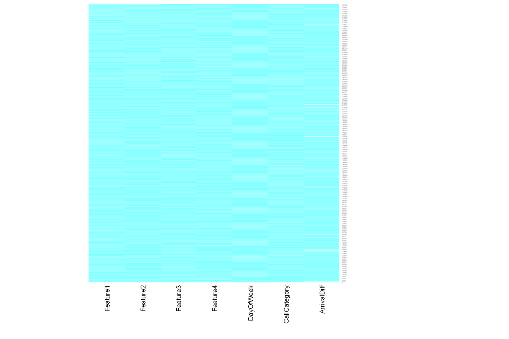

```r
options(repr.plot.width=15, repr.plot.height=10)
nba_heatmap <- heatmap(mat, Rowv=NA, Colv=NA, col = cm.colors(256), scale="column", margins=c(10,15))
#nba_heatmap
```

### Chi-Squared Test of Independence

We perform the chi-squared. The Chi-Square test of independence is used to determine if there is a significant relationship between two nominal (categorical) variables. The frequency of each category for one nominal variable is compared across the categories of the second nominal variable. The data can be displayed in a contingency table where each row represents a category for one variable and each column represents a category for the other variable. The chi-square test of independence can be used to examine this relationship. The null hypothesis for this test is that there is no relationship between the two variables. The alternative hypothesis is that there is a relationship between the two variables.[1]

```r
chisq.test(val$Feature1, val$Feature2, correct=FALSE)
```

```
	Pearson's Chi-squared test

data:  val$Feature1 and val$Feature2
X-squared = 2.7468, df = 3, p-value = 0.4323
```

We perform the chi-squared test on categorical variables so we filter out all non-categorical ones and create a new dataframe.

```r
is.fact <- sapply(val, is.factor)
v1 <- val[, is.fact]
v1
```

A data.frame: 332888 × 6

|  | Feature1 <fct> | Feature2 <fct> | Feature3 <fct> | Feature4 <fct> | DayOfWeek <fct> | CallCategory <fct> |
| --- | --- | --- | --- | --- | --- | --- |
| 1 | A- | PreQ | F | TMO | Saturday | PostQ |
| 2 | AB+ | PostQ | M | SPR | Saturday | PostQ |
| 3 | A+ | PostQ | M | SPR | Saturday | PreQ |
| 4 | A+ | PreQ | I | SPR | Saturday | PostQ |
| 5 | AB+ | PostQ | F | TMO | Saturday | PreQ |
| 6 | AB+ | PostQ | F | SPR | Saturday | PostQ |
| 7 | AB+ | PostQ | I | SPR | Saturday | PostQ |
| 8 | A- | PreQ | I | TMO | Saturday | PreQ |
| 9 | A- | PreQ | I | SPR | Saturday | PostQ |
| 10 | AB+ | PreQ | F | TMO | Saturday | PreQ |
| 11 | A+ | PostQ | F | TMO | Saturday | PreQ |
| 12 | A+ | PostQ | I | TMO | Saturday | PreQ |
| 13 | AB+ | PostQ | M | TMO | Saturday | PostQ |
| 14 | AB+ | PreQ | I | TMO | Saturday | PreQ |
| 15 | A+ | PreQ | F | VER | Saturday | PostQ |
| 16 | AB+ | PostQ | I | VER | Saturday | PostQ |
| 17 | A+ | PostQ | M | TMO | Saturday | PreQ |
| 18 | A+ | PreQ | I | SPR | Saturday | PostQ |
| 19 | A+ | PostQ | F | TMO | Saturday | PostQ |
| 20 | A+ | PostQ | M | SPR | Saturday | PostQ |
| 21 | A+ | PostQ | I | SPR | Saturday | PreQ |
| 22 | AB+ | PostQ | I | SPR | Saturday | PostQ |
| 23 | A- | PreQ | M | SPR | Saturday | PreQ |
| 24 | A- | PostQ | F | TMO | Saturday | PreQ |
| 25 | AB+ | PreQ | F | SPR | Saturday | PreQ |
| 26 | A- | PostQ | M | SPR | Saturday | PreQ |
| 27 | A- | PreQ | F | SPR | Saturday | PostQ |
| 28 | AB+ | PreQ | I | SPR | Saturday | PreQ |
| 29 | A- | PreQ | M | SPR | Saturday | PostQ |
| 30 | AB+ | PostQ | F | TMO | Saturday | PostQ |
| ... | ... | ... | ... | ... | ... | ... |
| 332859 | AB- | PreQ | F | TMO | Monday | PreQ |
| 332860 | A- | PostQ | F | SPR | Monday | PostQ |
| 332861 | A+ | PostQ | F | TMO | Monday | PreQ |
| 332862 | A- | PostQ | M | VER | Monday | PreQ |
| 332863 | A+ | PostQ | I | TMO | Monday | PreQ |
| 332864 | AB+ | PostQ | M | SPR | Monday | PostQ |
| 332865 | A- | PreQ | M | SPR | Monday | PreQ |
| 332866 | AB+ | PostQ | F | SPR | Monday | PostQ |
| 332867 | AB+ | PreQ | I | TMO | Monday | PostQ |
| 332868 | A+ | PreQ | M | SPR | Monday | PostQ |
| 332869 | A- | PreQ | M | TMO | Monday | PreQ |
| 332870 | AB+ | PostQ | I | VER | Monday | PostQ |
| 332871 | A- | PreQ | M | VER | Monday | PostQ |
| 332872 | AB+ | PostQ | I | SPR | Monday | PreQ |
| 332873 | AB+ | PreQ | M | TMO | Monday | PreQ |
| 332874 | AB+ | PreQ | M | VER | Monday | PostQ |
| 332875 | A- | PostQ | M | VER | Monday | PreQ |
| 332876 | AB+ | PreQ | I | TMO | Monday | PreQ |
| 332877 | AB+ | PostQ | M | TMO | Monday | PostQ |
| 332878 | AB+ | PreQ | I | TMO | Monday | PostQ |
| 332879 | A+ | PreQ | F | TMO | Monday | PostQ |
| 332880 | AB+ | PreQ | I | VER | Monday | PreQ |
| 332881 | A+ | PreQ | F | TMO | Monday | PreQ |
| 332882 | A+ | PostQ | I | SPR | Monday | PostQ |
| 332883 | A- | PostQ | M | SPR | Monday | PreQ |
| 332884 | AB- | PreQ | I | SPR | Monday | PostQ |
| 332885 | A- | PreQ | M | SPR | Monday | PreQ |
| 332886 | A- | PreQ | M | SPR | Monday | PostQ |
| 332887 | A+ | PreQ | M | TMO | Monday | PreQ |
| 332888 | AB+ | PostQ | M | SPR | Monday | PostQ |

```r
combos <- combn(ncol(v1),2)

adply(combos, 2, function(x) {
  test <- chisq.test(v1[, x[1]], v1[, x[2]])

  out <- data.frame("Row" = colnames(v1)[x[1]]
                    , "Column" = colnames(v1[x[2]])
                    , "Chi.Square" = test$statistic
                    ,  "df"= test$parameter
                    ,  "p.value" = test$p.value
                    )
  return(out)

})
```

A data.frame: 15 × 6

| X1 <fct> | Row <fct> | Column <fct> | Chi.Square <dbl> | df <int> | p.value <dbl> |
| --- | --- | --- | --- | --- | --- |
| 1 | Feature1 | Feature2 | 2.746841e+00 | 3 | 4.323257e-01 |
| 2 | Feature1 | Feature3 | 4.129566e+00 | 6 | 6.591475e-01 |
| 3 | Feature1 | Feature4 | 1.107994e+01 | 6 | 8.593689e-02 |
| 4 | Feature1 | DayOfWeek | 2.382340e+01 | 18 | 1.608991e-01 |
| 5 | Feature1 | CallCategory | 2.188285e+00 | 3 | 5.342596e-01 |
| 6 | Feature2 | Feature3 | 6.811349e+00 | 2 | 3.318442e-02 |
| 7 | Feature2 | Feature4 | 1.449107e+00 | 2 | 4.845408e-01 |
| 8 | Feature2 | DayOfWeek | 5.014970e+00 | 6 | 5.418945e-01 |
| 9 | Feature2 | CallCategory | 1.081661e-04 | 1 | 9.917019e-01 |
| 10 | Feature3 | Feature4 | 3.373027e+00 | 4 | 4.974455e-01 |
| 11 | Feature3 | DayOfWeek | 5.885225e+02 | 12 | 2.991257e-118 |
| 12 | Feature3 | CallCategory | 2.960758e-03 | 2 | 9.985207e-01 |
| 13 | Feature4 | DayOfWeek | 8.149253e+00 | 12 | 7.733607e-01 |
| 14 | Feature4 | CallCategory | 1.389761e+00 | 2 | 4.991342e-01 |
| 15 | DayOfWeek | CallCategory | 1.365679e-03 | 6 | 1.000000e+00 |

### Cramer's V Test:

We also perform the perform the Cramer's V test to gauge the strength of the relationship between the features. For Cramer's V the range is 0 to 1. A Cramer's V value in the range of [0, 0.3] is considered as weak, [0.3,0.5] as medium and > 0.5 as strong. The minimum value for all is 0 under statistical independence.[2]

```r
CramerV(val$Feature1, val$Feature2, conf=0.95)
```

**Cramer V**

0.00287255067876942

**lwr.ci**

0

**upr.ci**

0.00549746288531012

We make all combinations of two variables and then perform the Cramer's V test. From the table below we can see all the associations are very weak. Even the variables which appeared not to be independent also have very weak associations.

```r
combos <- combn(ncol(v1),2)

adply(combos, 2, function(x) {
  test <- CramerV(v1[, x[1]], v1[, x[2]])

  out <- data.frame("Row" = colnames(v1)[x[1]]
                    , "Column" = colnames(v1[x[2]])
                    , "Cramer V" = test
                    )
  return(out)

})
```

A data.frame: 15 × 4

| X1 <fct> | Row <fct> | Column <fct> | Cramer.V <dbl> |
| --- | --- | --- | --- |
| 1 | Feature1 | Feature2 | 2.872551e-03 |
| 2 | Feature1 | Feature3 | 2.490509e-03 |
| 3 | Feature1 | Feature4 | 4.079479e-03 |
| 4 | Feature1 | DayOfWeek | 4.884186e-03 |
| 5 | Feature1 | CallCategory | 2.563911e-03 |
| 6 | Feature2 | Feature3 | 4.523426e-03 |
| 7 | Feature2 | Feature4 | 2.086417e-03 |
| 8 | Feature2 | DayOfWeek | 3.881371e-03 |
| 9 | Feature2 | CallCategory | 2.403451e-05 |
| 10 | Feature3 | Feature4 | 2.250846e-03 |
| 11 | Feature3 | DayOfWeek | 2.973155e-02 |
| 12 | Feature3 | CallCategory | 9.430883e-05 |
| 13 | Feature4 | DayOfWeek | 3.498604e-03 |
| 14 | Feature4 | CallCategory | 2.043247e-03 |
| 15 | DayOfWeek | CallCategory | 6.405091e-05 |

```r
#PairApply(v1, CramerV, symmetric = TRUE)
```

We perform the point biserial test on ArrivalDiff and CallCategory and ArrivalDiff and Feature2. The point biserial correlation coefficient, rpbi, is a special case of Pearson’s correlation coefficient. It measures the relationship between two variables: One continuous variable (must be ratio scale or interval scale). One naturally binary variable.The value of point biserial correlation ranges from -1 to +1 [3]

CallCategory and Feature2 are both dichotomous. We cannot test correlation between Arrival Diff and remaining features because the notion of correlation between categorical and continuous variables is relevant for only dichotomous variables. The point biserial correlation also shows that ArrivalDiff has very weak correlations with CallCategory and Feature2.

```r
biserial.cor(val$ArrivalDiff,val$CallCategory,level=1)
biserial.cor(val$ArrivalDiff,val$Feature2,level=1)
```

-0.00136227740388499

0.00112700191047726

The objective of finding the correlations was to find if there is multicollinearity among our explanatory variables. If there is multicollinearlity then it effects our regression cofficients and ultimately our regression results.

### Generalized Linear Model:

In these models, the response variable $y_{i}$ is assumed to follow an exponential family distribution with mean $μ_i$, which is assumed to be some (often nonlinear) function of $x^T_iβ$. The covariates affect the distribution of $y_i$ only through the linear combination $x^T_iβ$.The generalized linear models (GLMs) are a broad class of models that include linear regression, ANOVA, Poisson regression, log-linear models etc.The table below provides a good summary of GLMs:

[figure not shown]

**There are three components to any GLM:**

Random Component – refers to the probability distribution of the response variable (Y); e.g. normal distribution for Y in the linear regression, or binomial distribution for Y in the binary logistic regression. Also called a noise model or error model. How is random error added to the prediction that comes out of the link function?

Systematic Component - specifies the explanatory variables $(X_1, X_2, ... X_k)$ in the model, more specifically their linear combination in creating the so called linear predictor; e.g., $β_0 + β_1x_1 + β_2x_2$ as we have seen in a linear regression, or as we will see in a logistic regression in this lesson.

Link Function, η or g(μ) - specifies the link between random and systematic components. It says how the expected value of the response relates to the linear predictor of explanatory variables; e.g., η = $g(E(Y_i)) = E(Y_i)$ for linear regression, or η = logit(π) for logistic regression.

**Assumptions:**

The data $Y_1, Y_2, ..., Y_n$ are independently distributed, i.e., cases are independent.

The dependent variable Yi does NOT need to be normally distributed, but it typically assumes a distribution from an exponential family (e.g. binomial, Poisson, multinomial, normal,...)

GLM does NOT assume a linear relationship between the dependent variable and the independent variables, but it does assume linear relationship between the transformed response in terms of the link function and the explanatory variables; e.g., for binary logistic regression logit(π) = $β_0 + β_X$.

Independent (explanatory) variables can be even the power terms or some other nonlinear transformations of the original independent variables.

The homogeneity of variance does NOT need to be satisfied. In fact, it is not even possible in many cases given the model structure, and overdispersion (when the observed variance is larger than what the model assumes) maybe present.

Errors need to be independent but NOT normally distributed. It uses maximum likelihood estimation (MLE) rather than ordinary least squares (OLS) to estimate the parameters, and thus relies on large-sample approximations.

Goodness-of-fit measures rely on sufficiently large samples, where a heuristic rule is that not more than 20% of the expected cells counts are less than 5.[4]

#### Logistic Regression

Since our response variable has two categories we have used logistic regression.

Binary Logistic Regression models how binary response variable Y depends on a set of k explanatory variables, $X=(X_1, X_2, ... X_k).$

$logit(\pi)$ = $log(\frac{\pi}{1-\pi})$= $β_0+βx_i....+β_0+βx_k$

which models the log odds of probability of "success" as a function of explanatory variables.

Random component: The distribution of Y is assumed to be Binomial(n,π), where π is a probability of "success".

Systematic component: X's are explanatory variables (can be continuous, discrete, or both) and are linear in the parameters, e.g., $β_0+βx_i....+β_0+βx_k$. Again, transformation of the X's themselves are allowed like in linear regression; this holds for any GLM.

Link function:

Logit link:

$logit(\pi)$ = $log(\frac{\pi}{1-\pi})$

More generally, the logit link models the log odds of the mean, and the mean here is π. Binary logistic regression models are also known as logit models when the predictors are all categorical.[4]

### Fit Model

```r
fit<- glm(CallCategory~.,data=val,family=binomial(link="logit"), na.action = "na.fail")
```

The summary statistics helps us in understanding the model better by providing us with the following information:

Distribution of the deviance residuals

Intercept and slope estimates along with the standard error, z-value, and p-value

AIC value

Residual Deviance (for fitted model) and Null Deviance (for intercept model)

The coefficient table shows that none of the explanatory variables have significant influence (p-values > 0.05) on CallCategory.The difference between Null deviance and Residual deviance tells us that the model is a good fit. Greater the difference better the model. Null deviance is the value when you only have intercept in your equation with no variables and Residual deviance is the value when you are taking all the variables into account. It makes sense to consider the model good if that difference is big enough. The difference in our case doesn't seem to be very large.[7]

```r
summary(fit)
```

```
Call:
glm(formula = CallCategory ~ ., family = binomial(link = "logit"),
    data = val, na.action = "na.fail")

Deviance Residuals:
     Min        1Q    Median        3Q       Max
-1.20370  -1.17753  -0.00708   1.17728   1.18423

Coefficients:
                     Estimate Std. Error z value Pr(>|z|)
(Intercept)         1.003e-02  1.358e-02   0.739    0.460
Feature1A+         -7.736e-03  1.125e-02  -0.688    0.492
Feature1AB-        -1.390e-02  1.121e-02  -1.240    0.215
Feature1AB+        -1.065e-02  8.372e-03  -1.272    0.203
Feature2PreQ        9.919e-05  6.934e-03   0.014    0.989
Feature3I           4.720e-04  8.990e-03   0.053    0.958
Feature3M           1.152e-04  8.425e-03   0.014    0.989
Feature4TMO        -8.120e-03  7.715e-03  -1.053    0.293
Feature4VER        -9.120e-03  9.860e-03  -0.925    0.355
DayOfWeekMonday     8.860e-04  1.178e-02   0.075    0.940
DayOfWeekSaturday  -2.012e-03  1.557e-02  -0.129    0.897
DayOfWeekSunday    -3.056e-03  1.710e-02  -0.179    0.858
DayOfWeekThursday   1.247e-04  1.289e-02   0.010    0.992
DayOfWeekTuesday    6.570e-04  1.223e-02   0.054    0.957
DayOfWeekWednesday  4.274e-04  1.267e-02   0.034    0.973
ArrivalDiff         1.249e-04  1.499e-04   0.833    0.405

(Dispersion parameter for binomial family taken to be 1)

    Null deviance: 461481  on 332887  degrees of freedom
Residual deviance: 461476  on 332872  degrees of freedom
AIC: 461508

Number of Fisher Scoring iterations: 3
```

#### Pseudo R-squared and Likelihood ratio test

The nagelkerke( ) function provides three types of Pseudo R-squared value (McFadden, Cox and Snell, and Cragg and Uhler) and Likelihood ratio test results. The McFadden Pseudo R-squared value is the commonly reported metric for binary logistic regression model fit. The table result showed that the McFadden Pseudo R-squared value is 9.26211e-06, which indicates the model has no predictive ability, although the likelihood value for the current model will be (it is always) larger than the likelihood of the null model, it will not be much greater. Therefore $R^{2}_{\text{McFadden}}$ will be close to zero, as we would hope.[5,6]

Additionally, the table provides a Likelihood ratio test. Likelihood Ratio test (often termed as LR test) is a goodness of fit test used to compare between two models; the null model and the final model. The null hypothesis is that the smaller model is the “best” model; It is rejected when the test statistic is large. In other words, if the null hypothesis is rejected, then the larger model is a significant improvement over the smaller one. The test revealed that the Log-Likelihood difference between intercept only model (null model) and model fitted with all independent variables is 2.1371 and p-value 0.99 which shows the improvement is also not significant as (p-value > 0.05) and we donot reject the null hypothesis.[5,6]

```r
nagelkerke(fit)
```

**$Models**

A matrix: 2 × 1 of type chr

| Model: | glm, CallCategory ~ ., binomial(link = "logit"), val, na.fail |
| --- | --- |
| Null: | glm, CallCategory ~ 1, binomial(link = "logit"), val, na.fail |

**$Pseudo.R.squared.for.model.vs.null**

A matrix: 3 × 1 of type dbl

|  | Pseudo.R.squared |
| --- | --- |
| McFadden | 9.26211e-06 |
| Cox and Snell (ML) | 1.28399e-05 |
| Nagelkerke (Cragg and Uhler) | 1.71199e-05 |

**$Likelihood.ratio.test**

A matrix: 1 × 4 of type dbl

|  | Df.diff | LogLik.diff | Chisq | p.value |
| --- | --- | --- | --- | --- |
|  | -15 | -2.1371 | 4.2743 | 0.99669 |

**$Number.of.observations**

A matrix: 2 × 1 of type int

| Model: | 332888 |
| --- | --- |
| Null: | 332888 |

**$Messages**

'Note: For models fit with REML, these statistics are based on refitting with ML'

**$Warnings**

'None'

```r
confint.default(fit)
```

A matrix: 16 × 2 of type dbl

|  | 2.5 % | 97.5 % |
| --- | --- | --- |
| (Intercept) | -0.0165886850 | 0.0366578491 |
| Feature1A+ | -0.0297913695 | 0.0143187490 |
| Feature1AB- | -0.0358689753 | 0.0080693425 |
| Feature1AB+ | -0.0270583022 | 0.0057601751 |
| Feature2PreQ | -0.0134907174 | 0.0136890895 |
| Feature3I | -0.0171487381 | 0.0180927528 |
| Feature3M | -0.0163974983 | 0.0166279816 |
| Feature4TMO | -0.0232411233 | 0.0070003254 |
| Feature4VER | -0.0284444324 | 0.0102050102 |
| DayOfWeekMonday | -0.0222077227 | 0.0239797749 |
| DayOfWeekSaturday | -0.0325253950 | 0.0285005750 |
| DayOfWeekSunday | -0.0365634640 | 0.0304517606 |
| DayOfWeekThursday | -0.0251370509 | 0.0253864742 |
| DayOfWeekTuesday | -0.0233211860 | 0.0246351796 |
| DayOfWeekWednesday | -0.0243983409 | 0.0252530878 |
| ArrivalDiff | -0.0001689842 | 0.0004186953 |

Mathematically, one can compute the odds ratio by taking exponent of the estimated coefficients.

```r
exp(coef(fit))
```

**(Intercept)**

1.01008509729256

**Feature1A+**

0.992293537985704

**Feature1AB-**

0.986196340004141

**Feature1AB+**

0.98940743697483

**Feature2PreQ**

1.00009919099855

**Feature3I**

1.00047211877363

**Feature3M**

1.0001152482611

**Feature4TMO**

0.991912482390823

**Feature4VER**

0.99092174734586

**DayOfWeekMonday**

1.00088641873682

**DayOfWeekSaturday**

0.997989613538832

**DayOfWeekSunday**

0.996948812656381

**DayOfWeekThursday**

1.00012471944385

**DayOfWeekTuesday**

1.00065721265875

**DayOfWeekWednesday**

1.00042746478379

**ArrivalDiff**

1.00012486334219

```r
tidy(fit, exponentiate = TRUE, conf.level = 0.95)
```

A tibble: 16 × 5

| term <chr> | estimate <dbl> | std.error <dbl> | statistic <dbl> | p.value <dbl> |
| --- | --- | --- | --- | --- |
| (Intercept) | 1.0100851 | 0.013583549 | 0.738730502 | 0.4600707 |
| Feature1A+ | 0.9922935 | 0.011252788 | -0.687501642 | 0.4917667 |
| Feature1AB- | 0.9861963 | 0.011208961 | -1.240062930 | 0.2149521 |
| Feature1AB+ | 0.9894074 | 0.008372214 | -1.271953042 | 0.2033898 |
| Feature2PreQ | 1.0000992 | 0.006933752 | 0.014304822 | 0.9885868 |
| Feature3I | 1.0004721 | 0.008990341 | 0.052501606 | 0.9581290 |
| Feature3M | 1.0001152 | 0.008425022 | 0.013678495 | 0.9890865 |
| Feature4TMO | 0.9919125 | 0.007714797 | -1.052574545 | 0.2925360 |
| Feature4VER | 0.9909217 | 0.009859733 | -0.924945051 | 0.3549945 |
| DayOfWeekMonday | 1.0008864 | 0.011782741 | 0.075196940 | 0.9400580 |
| DayOfWeekSaturday | 0.9979896 | 0.015568136 | -0.129264676 | 0.8971482 |
| DayOfWeekSunday | 0.9969488 | 0.017096035 | -0.178746227 | 0.8581370 |
| DayOfWeekThursday | 1.0001247 | 0.012888891 | 0.009675903 | 0.9922799 |
| DayOfWeekTuesday | 1.0006572 | 0.012233992 | 0.053702570 | 0.9571721 |
| DayOfWeekWednesday | 1.0004275 | 0.012666414 | 0.033740683 | 0.9730839 |
| ArrivalDiff | 1.0001249 | 0.000149921 | 0.832808957 | 0.4049525 |

```r
exp(confint.default(fit))
```

A matrix: 16 × 2 of type dbl

|  | 2.5 % | 97.5 % |
| --- | --- | --- |
| (Intercept) | 0.9835481 | 1.037338 |
| Feature1A+ | 0.9706480 | 1.014422 |
| Feature1AB- | 0.9647667 | 1.008102 |
| Feature1AB+ | 0.9733045 | 1.005777 |
| Feature2PreQ | 0.9865999 | 1.013783 |
| Feature3I | 0.9829975 | 1.018257 |
| Feature3M | 0.9837362 | 1.016767 |
| Feature4TMO | 0.9770269 | 1.007025 |
| Feature4VER | 0.9719563 | 1.010257 |
| DayOfWeekMonday | 0.9780371 | 1.024270 |
| DayOfWeekSaturday | 0.9679979 | 1.028911 |
| DayOfWeekSunday | 0.9640969 | 1.030920 |
| DayOfWeekThursday | 0.9751763 | 1.025711 |
| DayOfWeekTuesday | 0.9769487 | 1.024941 |
| DayOfWeekWednesday | 0.9758969 | 1.025575 |
| ArrivalDiff | 0.9998310 | 1.000419 |

```r
predict(fit, type="response")
```

0.503371288475568

**2**

0.499902723603643

**3**

0.501598536979593

**4**

0.500370333178428

**5**

0.498655377750577

**6**

0.500092410404211

**7**

0.499617348469895

**8**

0.500305524908859

**9**

0.503521694155708

**10**

0.49955415997905

**11**

0.498072589139302

**12**

0.499938559096631

**13**

0.498465692522174

**14**

0.498049049485683

**15**

0.49809726836483

**16**

0.498305057606595

**17**

0.49888173903335

**18**

0.500370333178428

**19**

0.499976626690454

**20**

0.500131489740815

**21**

0.500969813247172

**22**

0.500959544351947

**23**

0.5032140194822

**24**

0.501005500176472

**25**

0.500117206922978

**26**

0.502408901421396

**27**

0.502092755084925

**28**

0.499579717240327

**29**

0.502496123616192

**30**

0.500184854956542

**31**

0.49802468968162

**32**

0.498680174094396

**33**

0.498839657772477

**34**

0.499929487264199

**35**

0.496993530220227

**36**

0.499997641591879

**37**

0.498178353417575

**38**

0.502659812445288

**39**

0.500019964681969

**40**

0.498902683883936

**41**

0.501598559935525

**42**

0.498159375860163

**43**

0.505357217386373

**44**

0.499172740266236

**45**

0.501781804319229

**46**

0.49692858443184

**47**

0.496968617676328

**48**

0.501678929658326

**49**

0.498065618603718

**50**

0.501774950698671

**51**

0.497993039956432

**52**

0.498954313775997

**53**

0.499399287816506

**54**

0.49862183057876

**55**

0.498517135302722

**56**

0.498475961359575

**57**

0.498802695331224

**58**

0.499969772983212

**59**

0.509174886160459

**60**

0.500248479819078

**61**

0.500555235813489

**62**

0.501363355538726

**63**

0.502122335005087

**64**

0.498343241704009

**65**

0.4976564303599

**66**

0.500273276332184

**67**

0.49832985384566

**68**

0.497780273107226

**69**

0.498684257899339

**70**

0.504065569941968

**71**

0.503517059102141

**72**

0.501120063316168

**73**

0.500836043311969

**74**

0.498684257899339

**75**

0.49737322583289

**76**

0.502127982229466

**77**

0.502278837746781

**78**

0.500516133563641

**79**

0.498365634499595

**80**

0.499339078264037

**81**

0.50061531477103

**82**

0.499489211850869

**83**

0.499711426428062

**84**

0.497712556495113

**85**

0.498029979813445

**86**

0.499679085400411

**87**

0.497080315125378

**88**

0.500588830181914

**89**

0.500060264077299

**90**

0.499578590088304

**91**

0.500287582102573

**92**

0.497612063324374

**93**

0.501130355153664

**94**

0.499529363480021

**95**

0.497586459649972

**96**

0.500218300639444

**97**

0.500746774321105

**98**

0.500100298811814

**99**

0.500253964743868

**100**

0.501334109006142

**101**

0.502309934046543

**102**

0.502247188168021

**103**

0.499405705174334

**104**

0.497935063369615

**105**

0.497649693733346

**106**

0.501587669497388

**107**

0.497111527959231

**108**

0.497491543960282

**109**

0.503802604059687

**110**

0.498649030377746

**111**

0.49883383909606

**112**

0.500023128924277

**113**

0.500337922206983

**114**

0.496681286922267

**115**

0.497836973237287

**116**

0.502083669734642

**117**

0.502935072196969

**118**

0.500115573481937

**119**

0.50059731723695

**120**

0.500091477963425

**121**

0.50087660824491

**122**

0.499314718128595

**123**

0.500066681444188

**124**

0.50031226168127

**125**

0.500422491985852

**126**

0.498960731115093

**127**

0.500147223706863

**128**

0.497841423379713

**129**

0.500311825341172

**130**

0.50012465899017

**131**

0.502647738812021

**132**

0.500468011611467

**133**

0.500693245286888

**134**

0.500443651452125

**135**

0.502473731131152

**136**

0.498906535431909

**137**

0.500037871039379

**138**

0.500811246859399

**139**

0.49881151612973

**140**

0.500219920404095

**141**

0.497812613518742

**142**

0.502901892299157

**143**

0.498646556966075

**144**

0.499537228924897

**145**

0.502497307011378

**146**

0.497687760499878

**147**

0.502398034079979

**148**

0.497778996803495

**149**

0.502785861354761

**150**

0.501153680510932

**151**

0.498773698216108

**152**

0.501983176029274

**153**

0.497059969529674

**154**

0.499835084848557

**155**

0.498524105881239

**156**

0.506056634677474

**157**

0.499777868069613

**158**

0.500811246859399

**159**

0.498530406261291

**160**

0.502522886603312

**161**

0.50400314623265

**162**

0.498022286237456

**163**

0.49968662991719

**164**

0.502928655050627

**165**

0.503753450166822

**166**

0.49767448971107

**167**

0.498684071020315

**168**

0.500365284513841

**169**

0.498992311261843

**170**

0.50087035321582

**171**

0.499193876735824

**172**

0.501683379833554

**173**

0.500525205386394

**174**

0.501935054769287

**175**

0.497905009399485

**176**

0.49809353378484

**177**

0.497736916170268

**178**

0.49914597668058

**179**

0.497466748070723

**180**

0.497469268420091

**181**

0.501375591521837

**182**

0.501161568876544

**183**

0.497966276732097

**184**

0.500285061689398

**185**

0.502969538006816

**186**

0.504814630336106

**187**

0.499735786600206

**188**

0.497799342700023

**189**

0.502567370411753

**190**

0.498461242338662

**191**

0.496928701359707

**192**

0.498240780390716

**193**

0.505219186684617

**194**

0.499465729389798

**195**

0.497961826580344

**196**

0.50331647762136

**197**

0.497466865000001

**198**

0.499523706878693

**199**

0.501908291503312

**200**

0.49840908400934

**201**

...

**202**

0.500905277435339

**203**

0.498249873387878

**204**

0.499440008060314

**205**

0.498124902551252

**206**

0.497031315453137

**207**

0.49791042260322

**208**

0.500816086264835

**209**

0.497287552571245

**210**

0.497316362137476

**211**

0.498091402594571

**212**

0.498125019481887

**213**

0.501509088352706

**214**

0.497434680125135

**215**

0.497534853549621

**216**

0.499433660649413

**217**

0.498819466916953

**218**

0.499383399072946

**219**

0.499508254466337

**220**

0.49827423327315

**221**

0.50085850140699

**222**

0.498715673886192

**223**

0.49816024676788

**224**

0.503784498209561

**225**

0.502910985101053

**226**

0.503534800497475

**227**

0.50120185269134

**228**

0.502814943108024

**229**

0.498946405903823

**230**

0.497006519814732

**231**

0.498347410871774

**232**

0.500760075997324

**233**

0.501373366341253

**234**

0.497966432057682

**235**

0.498915628497928

**236**

0.498815732303658

**237**

0.501134524345703

**238**

0.498659663865383

**239**

0.500884814274314

**240**

0.501529434459176

**241**

0.498940587221891

**242**

0.49810022331535

**243**

0.499652157671311

**244**

0.500678892391467

**245**

0.498617582697988

**246**

0.500692163440773

**247**

0.499044497393665

**248**

0.50043559897062

**249**

0.497842971940205

**250**

0.498826001179999

**251**

0.497846985750912

**252**

0.499467277977369

**253**

0.498982069863159

**254**

0.500784872457994

**255**

0.500096696549762

**256**

0.498467931903005

**257**

0.49821865989031

**258**

0.499414612914693

**259**

0.497530839762078

**260**

0.498684460210333

**261**

0.498030825941023

**262**

0.498184926025794

**263**

0.498975652522933

**264**

0.497843982141955

**265**

0.499564933431426

**266**

0.500914511637574

**267**

0.502886189414538

**268**

0.503341108969587

**269**

0.498780068397425

**270**

0.500824884133691

**271**

0.497592829721369

**272**

0.498904923275059

**273**

0.498097819868371

**274**

0.498249437052956

**275**

0.500847300065315

**276**

0.500936491216302

**277**

0.498523941802834

**278**

0.500219756324292

**279**

0.501165854999031

**280**

0.500335540002899

**281**

0.498093806041316

**282**

0.500760075997324

**283**

0.498315070192358

**284**

0.502318684604057

**285**

0.497904005348654

**286**

0.498373164035572

**287**

0.500940941426156

**288**

0.499910689559693

**289**

0.497492773110704

**290**

0.504475606678728

**291**

0.498374727512126

**292**

0.499023360946592

**293**

0.499286412306146

**294**

0.498711223690118

**295**

0.499533719569941

**296**

0.497430346946134

**297**

0.501317473271577

**298**

0.49929007698486

**299**

0.50070005183338

**300**

0.500974558671372

**301**

0.499315035774966

**302**

0.49785039938998

**303**

0.496975307058405

**304**

0.498029815736158

**305**

0.503222675892421

**306**

0.501076997792967

**307**

0.500624236186245

**308**

0.503410387292408

**309**

0.497780545362295

**310**

0.500856003956498

**311**

0.500279965957563

**312**

0.50071010621809

**313**

0.503254324791757

**314**

0.497686788696004

**315**

0.497372370964105

**316**

0.503278683931648

**317**

0.498915628497928

**318**

0.497846985750912

**319**

0.498285100737029

**320**

0.500918548465448

**321**

0.500856097932334

**322**

0.499308805300091

**323**

0.500815969332868

**324**

0.498372324055837

**325**

0.499377650321898

**326**

0.498561572737015

**327**

0.501165738067388

**328**

0.500870625475428

**329**

0.498281086899086

**330**

0.502883786012835

**331**

0.503622020323188

**332**

0.502972974388209

**333**

0.499071260959953

**334**

0.500472539381431

**335**

0.498122616034006

**336**

0.503133488061041

**337**

0.500279529617431

**338**

0.500315193717195

**339**

0.498808187826439

**340**

0.501159437666737

**341**

0.500814615227843

**342**

0.499404780335216

**343**

0.500346407590376

**344**

0.501449181517341

**345**

0.500697531424302

**346**

0.499591697073699

**347**

0.498003052496059

**348**

0.502997770024075

**349**

0.500279529617431

**350**

0.50110580806082

**351**

0.499970713850763

**352**

0.500407708176325

**353**

0.497561616567408

**354**

0.500910660083946

**355**

0.501373483272649

**356**

0.50080819787775

**357**

0.498405941075467

**358**

0.5028797722609

**359**

0.500976502849257

**360**

0.499433660649413

**361**

0.497128967668381

**362**

0.497912826043013

**363**

0.501446778055776

**364**

0.499491638130555

**365**

0.498247469935643

**366**

0.499234183632206

**367**

0.501123773740278

**368**

0.498068892956029

**369**

0.503465958731027

**370**

0.498308769829459

**371**

0.498780068397425

**372**

0.498123892344925

**373**

0.502917402250046

**374**

0.499359038931882

**375**

0.500635103761541

**376**

0.499227329941168

**377**

0.500346407590376

**378**

0.503314346493777

**379**

0.500629735776233

**380**

0.498180592789774

**381**

0.501130604456656

**382**

0.501752496418631

**383**

0.498249320122111

**384**

0.500659900239813

**385**

0.500529240543736

**386**

0.498185042956532

**387**

0.49815371255739

**388**

0.500635103761541

**389**

0.498555155423372

**390**

0.49853480930135

**391**

0.498211806270376

**392**

0.498884414762153

**393**

0.498336543398745

**394**

0.498853201035074

**395**

0.500976502849257

**396**

0.502790147367201

**397**

0.500552909883054

**398**

0.503407983922425

**399**

0.503127070945575

**400**

0.499162935192958

**401**

0.500596118458187

```r
residuals(fit, type="deviance")
```

-1.18314208054683

**2**

-1.17724478906485

**3**

1.17469588096241

**4**

-1.17803915159526

**5**

1.1796949161311

**6**

-1.17756699890056

**7**

-1.1767601031602

**8**

1.17689108872244

**9**

-1.18339806542189

**10**

1.17816744003981

**11**

1.18068577636536

**12**

1.17751439049998

**13**

-1.17480488949741

**14**

1.18072580548107

**15**

-1.17417966235799

**16**

-1.17453227157089

**17**

1.17931014346841

**18**

-1.17803915159526

**19**

-1.17737031985136

**20**

-1.17763338490953

**21**

1.17576309919321

**22**

-1.17904038359498

**23**

1.17195538594932

**24**

1.17570251302052

**25**

1.17721093622564

**26**

1.17332088210152

**27**

-1.18096695508024

**28**

1.1781240168612

**29**

-1.18165302071936

**30**

-1.1777240413888

**31**

1.18076722982346

**32**

-1.17516892956789

**33**

-1.17543964943695

**34**

1.17752980087688

**35**

1.18252126461707

**36**

1.17741402861297

**37**

1.18050593110019

**38**

-1.18193147435462

**39**

-1.17744393558342

**40**

-1.17554664136776

**41**

1.17469584200293

**42**

-1.17428505184352

**43**

1.16832336158072

**44**

1.1788155667927

**45**

-1.18043818472398

**46**

-1.1721972015832

**47**

-1.17226508992043

**48**

-1.18026326735882

**49**

1.18069762968606

**50**

1.17439649624004

**51**

-1.17400280643438

**52**

-1.17563429006385

**53**

1.17843058956882

**54**

1.17975194435028

**55**

1.17992992710956

**56**

-1.17482231784088

**57**

1.17944449768498

**58**

1.17746136787662

**59**

-1.19303595776679

**60**

1.17698797306118

**61**

-1.17835331646954

**62**

1.17509504314781

**63**

-1.18101726046293

**64**

-1.17459707267413

**65**

1.18139353216693

**66**

-1.17787425698898

**67**

1.18024833327512

**68**

-1.17364181254824

**69**

1.17964582244157

**70**

1.17051178574307

**71**

-1.18339017640208

**72**

-1.17931320693814

**73**

-1.17883049390571

**74**

1.17964582244157

**75**

-1.17295130672008

**76**

1.17379746728562

**77**

1.17354152872308

**78**

1.17653342141565

**79**

1.18018749826648

**80**

-1.17628755834106

**81**

-1.17845540259134

**82**

-1.17654249877822

**83**

1.17790024562129

**84**

-1.17352692899483

**85**

-1.1740654852415

**86**

1.17795519084527

**87**

1.18237360093289

**88**

-1.17841039957279

**89**

1.1773076570449

**90**

1.17812593194077

**91**

1.17692156212582

**92**

-1.17335644670363

**93**

-1.17933070012674

**94**

1.17820957123557

**95**

-1.17331301267622

**96**

1.17703923007151

**97**

-1.17867879055977

**98**

1.17723965534069

**99**

-1.1778414486573

**100**

-1.17967704445804

**101**

1.17348877395854

**102**

1.17359522304209

**103**

-1.17640069425521

**104**

1.18091964612311

**105**

-1.17342028396149

**106**

1.17471432468265

**107**

-1.17250744904433

**108**

-1.17315200315284

**109**

1.17095751096337

**110**

-1.17511606660059

**111**

1.17939156048092

**112**

1.17737073496945

**113**

-1.17798408602128

**114**

1.1830526043991

**115**

-1.17373800952712

**116**

-1.18095150415955

**117**

1.17242841856842

**118**

-1.1776063469958

**119**

-1.17842482083366

**120**

-1.17756541493479

**121**

1.17592134019261

**122**

-1.17624619462282

**123**

1.17729675661119

**124**

1.176879647314

**125**

1.17669244357752

**126**

1.17917588296859

**127**

-1.17766011338741

**128**

-1.17374555972851

**129**

-1.17793974870811

**130**

1.17719827867201

**131**

-1.18191093481852

**132**

-1.17820511128256

**133**

1.17623267279625

**134**

-1.17816372151788

**135**

1.17321090752795

**136**

1.1792679971218

**137**

-1.17747435259311

**138**

1.17603231389455

**139**

1.17942950427137

**140**

1.17703647900426

**141**

-1.1736966806623

**142**

-1.18234332794311

**143**

1.17970991084136

**144**

1.17819620716479

**145**

-1.18165503371812

**146**

1.18134024357425

**147**

1.17333931741263

**148**

-1.17363964721598

**149**

-1.1821459158791

**150**

1.17545095806492

**151**

-1.17532768172594

**152**

-1.18078060574721

**153**

1.18240821811009

**154**

1.1776901674624

**155**

-1.17490403037459

**156**

1.16713897177489

**157**

-1.17703272287149

**158**

-1.1787883541562

**159**

-1.17491472375568

**160**

1.1731275247021

**161**

1.17061758777592

**162**

1.1807713169602

**163**

-1.17687776486254

**164**

-1.18238886326117

**165**

1.17104083342837

**166**

1.18136281538601

**167**

1.17964614011675

**168**

1.17678959739446

**169**

-1.1756987975092

**170**

-1.17888880203476

**171**

1.17877964705567

**172**

-1.18027083376267

**173**

-1.17830229007735

**174**

-1.18069877475209

**175**

-1.17385344305603

**176**

1.18065016050325

**177**

1.18125663793228

**178**

1.1788610499746

**179**

-1.17310994220035

**180**

-1.17311421741107

**181**

1.1750742743277

**182**

1.17543756713773

**183**

1.18086656456675

**184**

-1.17789427922957

**185**

1.17236996834523

**186**

-1.18559951277458

**187**

-1.1769612511282

**188**

1.18115046413171

**189**

1.17305206837923

**190**

-1.17479733664501

**191**

-1.17219739986722

**192**

1.18039978316072

**193**

-1.18628867975885

**194**

-1.17650262203138

**195**

1.18087413245327

**196**

1.17178165762355

**197**

1.18171597908858

**198**

-1.17660107745971

**199**

-1.18065326434468

**200**

1.18011362616658

**201**

...

**202**

-1.17894815531997

**203**

1.18038432216199

**204**

1.17836139795051

**205**

-1.17422655404464

**206**

1.18245697250298

**207**

-1.17386262755032

**208**

1.17602409718191

**209**

1.18202101808243

**210**

1.18197200631592

**211**

-1.17416970898591

**212**

-1.1742267524625

**213**

-1.17997450917047

**214**

1.18177072838557

**215**

1.18160032790383

**216**

-1.17644816533098

**217**

1.17941598974908

**218**

-1.17636281688489

**219**

1.17824543756548

**220**

1.18034290297095

**221**

-1.17886866029489

**222**

-1.1752291875894

**223**

-1.17428652970217

**224**

-1.18384540139315

**225**

1.17246926828215

**226**

1.17141150074368

**227**

1.17536918409154

**228**

1.17263215282749

**229**

-1.17562086522377

**230**

-1.17232936568587

**231**

1.18021848230185

**232**

-1.17870139489009

**233**

-1.17974377933053

**234**

-1.17395765947074

**235**

-1.17556861635912

**236**

1.17942233773114

**237**

-1.17933778659305

**238**

1.1796876300658

**239**

-1.17891337828602

**240**

1.17481316000688

**241**

1.17921012037961

**242**

1.18063878520793

**243**

1.17800093999808

**244**

-1.17856343738289

**245**

1.17975916557481

**246**

-1.17858598880791

**247**

-1.17578739489312

**248**

1.17667018479383

**249**

1.18107626262626

**250**

1.17940488303969

**251**

-1.17375499698547

**252**

-1.17650525174974

**253**

1.17913961515518

**254**

-1.17874353344257

**255**

-1.17757427991811

**256**

-1.17480869018202

**257**

1.1804373954075

**258**

1.17840454905948

**259**

-1.17321866128453

**260**

1.17964547853366

**261**

-1.1740669209486

**262**

-1.17432840866249

**263**

1.17915052216435

**264**

1.18107454456886

**265**

1.17814913528184

**266**

-1.17896384892882

**267**

1.17251132026369

**268**

-1.18309071881809

**269**

1.179482958827

**270**

-1.17881152962939

**271**

-1.17332381879733

**272**

1.17927073728092

**273**

1.18064287217426

**274**

-1.17443788200068

**275**

-1.17884962412477

**276**

1.17581967152436

**277**

-1.17490375189142

**278**

1.17703675768325

**279**

-1.17939104051786

**280**

-1.1779800387449

**281**

1.1806496975405

**282**

1.17611919704316

**283**

-1.17454926350301

**284**

1.17347392882936

**285**

1.18097246443955

**286**

-1.1746478539273

**287**

-1.17900876703991

**288**

-1.17725831968191

**289**

1.18167190784891

**290**

1.16981690177282

**291**

-1.17465050732964

**292**

-1.1757515108392

**293**

1.17862239528397

**294**

1.17959998371291

**295**

-1.17661808099702

**296**

-1.17304819646278

**297**

1.17517292293719

**298**

1.17861616782287

**299**

-1.17859939359197

**300**

-1.17906590138447

**301**

1.17857375519724

**302**

-1.17376078866438

**303**

1.18255227208518

**304**

-1.17406520683565

**305**

1.17194070774252

**306**

1.17558113416011

**307**

1.17634985177118

**308**

1.1716224325456

**309**

-1.17364227444686

**310**

-1.17886441598112

**311**

1.17693449719872

**312**

-1.17861647914297

**313**

-1.18294302801255

**314**

1.18134189647504

**315**

1.18187672459641

**316**

1.17184573959732

**317**

-1.17556861635912

**318**

-1.17375499698547

**319**

1.18032442517163

**320**

1.17585013418188

**321**

-1.17886457568906

**322**

-1.17623615467361

**323**

1.17602429571769

**324**

-1.17464642838452

**325**

1.17846735652524

**326**

-1.17496762190324

**327**

-1.17939084176287

**328**

1.17593149785948

**329**

1.18033124983182

**330**

1.17251539631737

**331**

-1.18356882915551

**332**

**334**

-1.17821280437051

**335**

-1.17422267408984

**336**

-1.18273739825001

**337**

1.1769352382697

**338**

1.17687466769937

**339**

1.17943516164475

**340**

-1.17938013265309

**341**

-1.17879407841647

**342**

-1.17639912380232

**343**

1.17682165621205

**344**

1.1749493688505

**345**

-1.17859511064207

**346**

-1.17671654016462

**347**

1.18080402477813

**348**

1.17232209076172

**349**

1.1769352382697

**350**

-1.17928897723702

**351**

1.17745976965147

**352**

-1.17810265218727

**353**

-1.17327086949434

**354**

-1.17895730316926

**355**

-1.17974397810837

**356**

1.17603749070005

**357**

1.18011896966709

**358**

-1.18230569246752

**359**

1.17575174207621

**360**

-1.17644816533098

**361**

1.18229082230837

**362**

1.18095746357487

**363**

-1.1798685783579

**364**

1.17827367068353

**365**

1.18038840879051

**366**

-1.17610945032974

**367**

-1.17931951358926

**368**

1.18069206167937

**369**

1.17152821424169

**370**

-1.17453857141506

**371**

-1.17533849506295

**372**

1.18059853725893

**373**

-1.18236971716814

**374**

1.178498981808

**375**

1.17633139809151

**376**

1.17872279688416

**377**

-1.17799850241674

**378**

1.17178527107194

**379**

-1.17847990726468

**380**

-1.17432105542557

**381**

-1.17933112387199

**382**

1.17443460089933

**383**

-1.17443768356893

**384**

-1.17853116441042

**385**

1.17651116379624

**386**

1.1804945563377

**387**

-1.17427544170252

**388**

1.17633139809151

**389**

1.17986529140037

**390**

-1.17492219688007

**391**

-1.17437402318608

**392**

-1.17551562767063

**393**

1.18023695946481

**394**

1.17935865012672

**395**

-1.17906920565402

**396**

1.17267420709135

**397**

-1.1783493643193

**398**

1.17162650739032

**399**

-1.1827264785427

**400**

1.17883222987413

**401**

AIC stands for Akaike Information Criteria. It is analogous to adjusted R² and is the measure of fit which penalizes model for the number of independent variables. We always prefer a model with minimum AIC value. Since from the table it shows that the null model is the best model we pick the model within two AIC values.[8]

```r
dredge(fit)
```

```
Fixed term is "(Intercept)"
```

A model.selection: 64 × 12

|  | (Intercept) <dbl> | ArrivalDiff <dbl> | DayOfWeek <fct> | Feature1 <fct> | Feature2 <fct> | Feature3 <fct> | Feature4 <fct> | df <int> | logLik <dbl> | AICc <dbl> | delta <dbl> | weight <mdl.wght> |
| --- | --- | --- | --- | --- | --- | --- | --- | --- | --- | --- | --- | --- |
| 1 | -9.090079e-18 | NA | NA | NA | NA | NA | NA | 1 | -230740.4 | 461482.8 | 0.000000 | 0.2940770568 |
| 2 | -2.294295e-03 | 0.0001087357 | NA | NA | NA | NA | NA | 2 | -230740.1 | 461484.1 | 1.382246 | 0.1473364327 |
| 9 | -4.739449e-05 | NA | NA | NA | + | NA | NA | 2 | -230740.4 | 461484.8 | 1.999832 | 0.1081940055 |
| 33 | 5.309531e-03 | NA | NA | NA | NA | NA | + | 3 | -230739.7 | 461485.4 | 2.610298 | 0.0797337306 |
| 10 | -2.344766e-03 | 0.0001087380 | NA | NA | + | NA | NA | 3 | -230740.1 | 461486.1 | 3.382065 | 0.0542069663 |
| 5 | 7.671892e-03 | NA | NA | + | NA | NA | NA | 4 | -230739.3 | 461486.6 | 3.811819 | 0.0437255404 |
| 34 | 3.015053e-03 | 0.0001083847 | NA | NA | NA | NA | + | 4 | -230739.4 | 461486.8 | 3.996556 | 0.0398676025 |
| 17 | -1.854504e-04 | NA | NA | NA | NA | + | NA | 3 | -230740.4 | 461486.8 | 3.997099 | 0.0398567657 |
| 41 | 5.265072e-03 | NA | NA | NA | + | NA | + | 4 | -230739.7 | 461487.4 | 4.610177 | 0.0293341711 |
| 6 | 5.379994e-03 | 0.0001084082 | NA | + | NA | NA | NA | 5 | -230739.0 | 461488.0 | 5.197826 | 0.0218659122 |
| 18 | -2.513636e-03 | 0.0001087350 | NA | NA | NA | + | NA | 4 | -230740.1 | 461488.1 | 5.379472 | 0.0199675024 |
| 13 | 7.626246e-03 | NA | NA | + | + | NA | NA | 5 | -230739.3 | 461488.6 | 5.811700 | 0.0160866814 |
| 42 | 2.967521e-03 | 0.0001083869 | NA | NA | + | NA | + | 5 | -230739.4 | 461488.8 | 5.996423 | 0.0146674429 |
| 25 | -2.337638e-04 | NA | NA | NA | + | + | NA | 4 | -230740.4 | 461488.8 | 5.996950 | 0.0146635766 |
| 37 | 1.297423e-02 | NA | NA | + | NA | NA | + | 6 | -230738.6 | 461489.2 | 6.424079 | 0.0118437747 |
| 49 | 5.106060e-03 | NA | NA | NA | NA | + | + | 5 | -230739.7 | 461489.4 | 6.607308 | 0.0108069343 |
| 14 | 5.331276e-03 | 0.0001084104 | NA | + | + | NA | NA | 6 | -230739.0 | 461490.0 | 7.197695 | 0.0080445467 |
| 26 | -2.565140e-03 | 0.0001087374 | NA | NA | + | + | NA | 5 | -230740.1 | 461490.1 | 7.379308 | 0.0073462336 |
| 21 | 7.497189e-03 | NA | NA | + | NA | + | NA | 6 | -230739.3 | 461490.6 | 7.809071 | 0.0059257436 |
| 38 | 1.068219e-02 | 0.0001080586 | NA | + | NA | NA | + | 7 | -230738.3 | 461490.6 | 7.814069 | 0.0059109535 |
| 50 | 2.777826e-03 | 0.0001083894 | NA | NA | NA | + | + | 6 | -230739.4 | 461490.8 | 7.993630 | 0.0054033922 |
| 45 | 1.293156e-02 | NA | NA | + | + | NA | + | 7 | -230738.6 | 461491.2 | 8.424007 | 0.0043572374 |
| 57 | 5.060652e-03 | NA | NA | NA | + | + | + | 6 | -230739.7 | 461491.4 | 8.607206 | 0.0039758507 |
| 22 | 5.171531e-03 | 0.0001084043 | NA | + | NA | + | NA | 7 | -230739.0 | 461492.0 | 9.195240 | 0.0029630579 |
| 29 | 7.450669e-03 | NA | NA | + | + | + | NA | 7 | -230739.3 | 461492.6 | 9.808972 | 0.0021800670 |
| 46 | 1.063645e-02 | 0.0001080607 | NA | + | + | NA | + | 8 | -230738.3 | 461492.6 | 9.813987 | 0.0021746080 |
| 58 | 2.729233e-03 | 0.0001083917 | NA | NA | + | + | + | 7 | -230739.4 | 461492.8 | 9.993515 | 0.0019879105 |
| 53 | 1.278148e-02 | NA | NA | + | NA | + | + | 8 | -230738.6 | 461493.2 | 10.421257 | 0.0016051437 |
| 30 | 5.121825e-03 | 0.0001084067 | NA | + | + | + | NA | 8 | -230739.0 | 461494.0 | 11.195128 | 0.0010901093 |
| 54 | 1.045581e-02 | 0.0001080601 | NA | + | NA | + | + | 9 | -230738.3 | 461494.6 | 11.811349 | 0.0008010496 |
| ... | ... | ... | ... | ... | ... | ... | ... | ... | ... | ... | ... | ... |
| 11 | -0.0001313793 | NA | + | NA | + | NA | NA | 8 | -230740.4 | 461496.8 | 13.99886 | 0.1906320869 |
| 35 | 0.0052002328 | NA | + | NA | NA | NA | + | 9 | -230739.7 | 461497.4 | 14.60939 | 0.1404827327 |
| 12 | -0.0027280324 | 0.0001257291 | + | NA | + | NA | NA | 9 | -230740.0 | 461498.1 | 15.29562 | 0.0996801743 |
| 7 | 0.0075836848 | NA | + | + | NA | NA | NA | 10 | -230739.3 | 461498.6 | 15.81096 | 0.0770377977 |
| 36 | 0.0026096815 | 0.0001254095 | + | NA | NA | NA | + | 10 | -230739.3 | 461498.7 | 15.90973 | 0.0733258106 |
| 19 | -0.0002733831 | NA | + | NA | NA | + | NA | 9 | -230740.4 | 461498.8 | 15.99623 | 0.0702221329 |
| 43 | 0.0051559890 | NA | + | NA | + | NA | + | 10 | -230739.7 | 461499.4 | 16.60934 | 0.0516819241 |
| 8 | 0.0049965545 | 0.0001251557 | + | + | NA | NA | NA | 11 | -230738.9 | 461499.9 | 17.11416 | 0.0401530885 |
| 20 | -0.0028576559 | 0.0001257336 | + | NA | NA | + | NA | 10 | -230740.0 | 461500.1 | 17.29295 | 0.0367192850 |
| 15 | 0.0075382468 | NA | + | + | + | NA | NA | 11 | -230739.3 | 461500.6 | 17.81092 | 0.0283412581 |
| 44 | 0.0025594988 | 0.0001254140 | + | NA | + | NA | + | 11 | -230739.3 | 461500.7 | 17.90965 | 0.0269761655 |
| 27 | -0.0003214664 | NA | + | NA | + | + | NA | 10 | -230740.4 | 461500.8 | 17.99615 | 0.0258342482 |
| 39 | 0.0128608135 | NA | + | + | NA | NA | + | 12 | -230738.6 | 461501.2 | 18.42336 | 0.0208654750 |
| 51 | 0.0049936124 | NA | + | NA | NA | + | + | 11 | -230739.7 | 461501.4 | 18.60656 | 0.0190391765 |
| 16 | 0.0049451815 | 0.0001251603 | + | + | + | NA | NA | 12 | -230738.9 | 461501.9 | 19.11408 | 0.0147720963 |
| 28 | -0.0029117189 | 0.0001257384 | + | NA | + | + | NA | 11 | -230740.0 | 461502.1 | 19.29284 | 0.0135090379 |
| 40 | 0.0102738805 | 0.0001248426 | + | + | NA | NA | + | 13 | -230738.2 | 461502.5 | 19.73007 | 0.0108562703 |
| 23 | 0.0074047921 | NA | + | + | NA | + | NA | 12 | -230739.3 | 461502.6 | 19.80839 | 0.0104393415 |
| 52 | 0.0024094932 | 0.0001254175 | + | NA | NA | + | + | 12 | -230739.3 | 461502.7 | 19.90684 | 0.0099379033 |
| 47 | 0.0128183298 | NA | + | + | + | NA | + | 13 | -230738.6 | 461503.2 | 20.42337 | 0.0076759724 |
| 59 | 0.0049484189 | NA | + | NA | + | + | + | 12 | -230739.7 | 461503.4 | 20.60653 | 0.0070042191 |
| 24 | 0.0048240655 | 0.0001251655 | + | + | NA | + | NA | 13 | -230738.9 | 461503.9 | 21.11151 | 0.0054413332 |
| 48 | 0.0102254769 | 0.0001248469 | + | + | + | NA | + | 14 | -230738.2 | 461504.5 | 21.73004 | 0.0039938615 |
| 31 | 0.0073584755 | NA | + | + | + | + | NA | 13 | -230739.3 | 461504.6 | 21.80837 | 0.0038404676 |
| 60 | 0.0023583354 | 0.0001254220 | + | NA | + | + | + | 13 | -230739.3 | 461504.7 | 21.90678 | 0.0036560663 |
| 55 | 0.0126644406 | NA | + | + | NA | + | + | 14 | -230738.6 | 461505.2 | 22.42071 | 0.0028275840 |
| 32 | 0.0047717884 | 0.0001251701 | + | + | + | + | NA | 14 | -230738.9 | 461505.9 | 23.11144 | 0.0020018167 |
| 56 | 0.0100839173 | 0.0001248512 | + | + | NA | + | + | 15 | -230738.2 | 461506.5 | 23.72735 | 0.0014712348 |
| 63 | 0.0126210507 | NA | + | + | + | + | + | 15 | -230738.6 | 461507.2 | 24.42073 | 0.0010401989 |
| 64 | 0.0100345820 | 0.0001248555 | + | + | + | + | + | 16 | -230738.2 | 461508.5 | 25.72734 | 0.0005412404 |

Alternatively, we can stepAIC function to perform stepwise regression.

The basic idea of the procedure is to start from a given model (which could well be the null model) and take a series of steps, by either deleting a term already in the model, or adding a term from a list of candidates for inclusion, called the scope of the search and defined, of course, by a model formula.

Selection of terms for deletion or inclusion is based on Akaike’s information criterion (AIC). R defines AIC as

AIC = –2 maximized log-likelihood + 2 number of parameters

The procedure stops when the AIC criterion cannot be improved.[8]

```r
#m <- stepAIC(fit)
#summary(m)
```

### Durbin Watson test

We perform the Durbin Watson test to check if there is any temporal auto correlation.[9] If there is auto-correlation then we will not randomly split the data when making predictions instead we will make the initial 80% of the data as train split and the remaining 20% of the data as test split.

```r
dwtest(fit,alternative='two.sided')
```

```
	Durbin-Watson test

data:  fit
DW = 2.3379, p-value < 2.2e-16
alternative hypothesis: true autocorrelation is not 0
```

### Train-Test Split

```r
n <- nrow(val)
n_train <- round(0.80 * n)
n
n_train
```

332888

266310

```r
df <- val[,c('Feature2','CallCategory')]
```

```r
new_train <- df[1:n_train,]
new_test <- df[n_train:n,]
```

### Final model

We have made a final model consisting of only Feature2 which we will be using for making predictions.

```r
log_model <- glm(CallCategory~Feature2,data=new_train,family=binomial(link="logit"), na.action = "na.fail")
```

```r
nagelkerke(log_model)
```

**$Models**

A matrix: 2 × 1 of type chr

| Model: | glm, CallCategory ~ Feature2, binomial(link = "logit"), new_train, na.fail |
| --- | --- |
| Null: | glm, CallCategory ~ 1, binomial(link = "logit"), new_train, na.fail |

**$Pseudo.R.squared.for.model.vs.null**

A matrix: 3 × 1 of type dbl

|  | Pseudo.R.squared |
| --- | --- |
| McFadden | 5.86003e-09 |
| Cox and Snell (ML) | 8.12373e-09 |
| Nagelkerke (Cragg and Uhler) | 1.08316e-08 |

**$Likelihood.ratio.test**

A matrix: 1 × 4 of type dbl

|  | Df.diff | LogLik.diff | Chisq | p.value |
| --- | --- | --- | --- | --- |
|  | -1 | -0.0010817 | 0.0021634 | 0.9629 |

**$Number.of.observations**

A matrix: 2 × 1 of type int

| Model: | 266310 |
| --- | --- |
| Null: | 266310 |

**$Messages**

'Note: For models fit with REML, these statistics are based on refitting with ML'

**$Warnings**

'None'

```r
summary(log_model)
```

```
Call:
glm(formula = CallCategory ~ Feature2, family = binomial(link = "logit"),
    data = new_train, na.action = "na.fail")

Deviance Residuals:
   Min      1Q  Median      3Q     Max
-1.177  -1.177   0.000   1.177   1.177

Coefficients:
               Estimate Std. Error z value Pr(>|z|)
(Intercept)  -0.0001774  0.0054382  -0.033    0.974
Feature2PreQ  0.0003606  0.0077521   0.047    0.963

(Dispersion parameter for binomial family taken to be 1)

    Null deviance: 369184  on 266309  degrees of freedom
Residual deviance: 369184  on 266308  degrees of freedom
AIC: 369188

Number of Fisher Scoring iterations: 2
```

```r
confint.default(log_model)
```

A matrix: 2 × 2 of type dbl

|  | 2.5 % | 97.5 % |
| --- | --- | --- |
| (Intercept) | -0.01083611 | 0.01048123 |
| Feature2PreQ | -0.01483330 | 0.01555444 |

```r
exp(coef(log_model))
```

**(Intercept)**

0.999822571821519

**Feature2PreQ**

1.00036063675818

```r
exp(confint.default(log_model))
```

A matrix: 2 × 2 of type dbl

|  | 2.5 % | 97.5 % |
| --- | --- | --- |
| (Intercept) | 0.9892224 | 1.010536 |
| Feature2PreQ | 0.9852762 | 1.015676 |

### Prediction on Test Data

```r
#prediction on test data
log_predict <- predict(log_model,newdata = new_test,type = "response")
predicted <- ifelse(log_predict > 0.5,'PreQ',"PostQ")
```

```r
tab <- table(Predicted = predicted, Reference = new_test$CallCategory)
tab
```

```
         Reference
Predicted PostQ  PreQ
    PostQ 16767 16775
    PreQ  16523 16514
```

```r
predicted
```

'PreQ'

**266312**

'PreQ'

**266313**

'PostQ'

**266314**

'PreQ'

**266315**

'PostQ'

**266316**

'PostQ'

**266317**

'PostQ'

**266318**

'PreQ'

**266319**

'PreQ'

**266320**

'PostQ'

**266321**

'PreQ'

**266322**

'PreQ'

**266323**

'PostQ'

**266324**

'PreQ'

**266325**

'PreQ'

**266326**

'PreQ'

**266327**

'PostQ'

**266328**

'PostQ'

**266329**

'PreQ'

**266330**

'PostQ'

**266331**

'PreQ'

**266332**

'PreQ'

**266333**

'PreQ'

**266334**

'PostQ'

**266335**

'PostQ'

**266336**

'PostQ'

**266337**

'PreQ'

**266338**

'PreQ'

**266339**

'PreQ'

**266340**

'PostQ'

**266341**

'PostQ'

**266342**

'PreQ'

**266343**

'PostQ'

**266344**

'PostQ'

**266345**

'PreQ'

**266346**

'PostQ'

**266347**

'PreQ'

**266348**

'PostQ'

**266349**

'PreQ'

**266350**

'PreQ'

**266351**

'PostQ'

**266352**

'PostQ'

**266353**

'PostQ'

**266354**

'PreQ'

**266355**

'PreQ'

**266356**

'PostQ'

**266357**

'PostQ'

**266358**

'PreQ'

**266359**

'PreQ'

**266360**

'PostQ'

**266361**

'PreQ'

**266362**

'PreQ'

**266363**

'PreQ'

**266364**

'PreQ'

**266365**

'PreQ'

**266366**

'PostQ'

**266367**

'PreQ'

**266368**

'PreQ'

**266369**

'PostQ'

**266370**

'PreQ'

**266371**

'PostQ'

**266372**

'PostQ'

**266373**

'PostQ'

**266374**

'PreQ'

**266375**

'PreQ'

**266376**

'PreQ'

**266377**

'PostQ'

**266378**

'PostQ'

**266379**

'PreQ'

**266380**

'PreQ'

**266381**

'PreQ'

**266382**

'PostQ'

**266383**

'PostQ'

**266384**

'PreQ'

**266385**

'PostQ'

**266386**

'PostQ'

**266387**

'PreQ'

**266388**

'PreQ'

**266389**

'PostQ'

**266390**

'PreQ'

**266391**

'PostQ'

**266392**

'PreQ'

**266393**

'PostQ'

**266394**

'PreQ'

**266395**

'PreQ'

**266396**

'PreQ'

**266397**

'PostQ'

**266398**

'PreQ'

**266399**

'PostQ'

**266400**

'PostQ'

**266401**

'PreQ'

**266402**

'PostQ'

**266403**

'PreQ'

**266404**

'PostQ'

**266405**

'PostQ'

**266406**

'PostQ'

**266407**

'PostQ'

**266408**

'PreQ'

**266409**

'PostQ'

**266410**

'PostQ'

**266411**

'PreQ'

**266412**

'PreQ'

**266413**

'PreQ'

**266414**

'PostQ'

**266415**

'PostQ'

**266416**

'PostQ'

**266417**

'PreQ'

**266418**

'PostQ'

**266419**

'PreQ'

**266420**

'PostQ'

**266421**

'PreQ'

**266422**

'PreQ'

**266423**

'PreQ'

**266424**

'PostQ'

**266425**

'PreQ'

**266426**

'PreQ'

**266427**

'PreQ'

**266428**

'PreQ'

**266429**

'PreQ'

**266430**

'PostQ'

**266431**

'PostQ'

**266432**

'PostQ'

**266433**

'PreQ'

**266434**

'PostQ'

**266435**

'PreQ'

**266436**

'PostQ'

**266437**

'PreQ'

**266438**

'PostQ'

**266439**

'PreQ'

**266440**

'PreQ'

**266441**

'PostQ'

**266442**

'PreQ'

**266443**

'PreQ'

**266444**

'PreQ'

**266445**

'PostQ'

**266446**

'PreQ'

**266447**

'PostQ'

**266448**

'PostQ'

**266449**

'PostQ'

**266450**

'PostQ'

**266451**

'PostQ'

**266452**

'PostQ'

**266453**

'PostQ'

**266454**

'PostQ'

**266455**

'PreQ'

**266456**

'PostQ'

**266457**

'PreQ'

**266458**

'PostQ'

**266459**

'PreQ'

**266460**

'PostQ'

**266461**

'PreQ'

**266462**

'PreQ'

**266463**

'PreQ'

**266464**

'PostQ'

**266465**

'PostQ'

**266466**

'PostQ'

**266467**

'PostQ'

**266468**

'PostQ'

**266469**

'PostQ'

**266470**

'PreQ'

**266471**

'PostQ'

**266472**

'PostQ'

**266473**

'PostQ'

**266474**

'PostQ'

**266475**

'PreQ'

**266476**

'PreQ'

**266477**

'PreQ'

**266478**

'PreQ'

**266479**

'PreQ'

**266480**

'PostQ'

**266481**

'PostQ'

**266482**

'PreQ'

**266483**

'PostQ'

**266484**

'PostQ'

**266485**

'PostQ'

**266486**

'PreQ'

**266487**

'PostQ'

**266488**

'PreQ'

**266489**

'PostQ'

**266490**

'PreQ'

**266491**

'PostQ'

**266492**

'PreQ'

**266493**

'PostQ'

**266494**

'PostQ'

**266495**

'PreQ'

**266496**

'PreQ'

**266497**

'PreQ'

**266498**

'PreQ'

**266499**

'PostQ'

**266500**

'PreQ'

**266501**

'PreQ'

**266502**

'PreQ'

**266503**

'PostQ'

**266504**

'PreQ'

**266505**

'PreQ'

**266506**

'PreQ'

**266507**

'PreQ'

**266508**

'PreQ'

**266509**

'PostQ'

**266511**

'PreQ'

**266512**

'PreQ'

**266513**

'PostQ'

**266514**

'PreQ'

**266515**

'PreQ'

**266516**

'PostQ'

**266517**

'PreQ'

**266518**

'PostQ'

**266519**

'PostQ'

**266520**

'PreQ'

**266521**

'PreQ'

**266522**

'PostQ'

**266523**

'PreQ'

**266524**

'PostQ'

**266525**

'PreQ'

**266526**

'PreQ'

**266527**

'PostQ'

**266528**

'PostQ'

**266529**

'PreQ'

**266530**

'PostQ'

**266531**

'PreQ'

**266532**

'PostQ'

**266533**

'PostQ'

**266534**

'PreQ'

**266535**

'PostQ'

**266536**

'PostQ'

**266537**

'PreQ'

**266538**

'PostQ'

**266539**

'PostQ'

**266540**

'PostQ'

**266541**

'PostQ'

**266542**

'PreQ'

**266543**

'PreQ'

**266544**

'PreQ'

**266545**

'PostQ'

**266546**

'PostQ'

**266547**

'PostQ'

**266548**

'PostQ'

**266549**

'PreQ'

**266550**

'PostQ'

**266551**

'PostQ'

**266552**

'PreQ'

**266553**

'PreQ'

**266554**

'PreQ'

**266555**

'PostQ'

**266556**

'PostQ'

**266557**

'PostQ'

**266558**

'PreQ'

**266559**

'PostQ'

**266560**

'PostQ'

**266561**

'PreQ'

**266562**

'PostQ'

**266563**

'PreQ'

**266564**

'PostQ'

**266565**

'PostQ'

**266566**

'PreQ'

**266567**

'PostQ'

**266568**

'PreQ'

**266569**

'PreQ'

**266570**

'PostQ'

**266571**

'PreQ'

**266572**

'PreQ'

**266573**

'PreQ'

**266574**

'PostQ'

**266575**

'PreQ'

**266576**

'PostQ'

**266577**

'PreQ'

**266578**

'PostQ'

**266579**

'PostQ'

**266580**

'PostQ'

**266581**

'PostQ'

**266582**

'PostQ'

**266583**

'PostQ'

**266584**

'PreQ'

**266585**

'PreQ'

**266586**

'PreQ'

**266587**

'PreQ'

**266588**

'PostQ'

**266589**

'PreQ'

**266590**

'PreQ'

**266591**

'PostQ'

**266592**

'PostQ'

**266593**

'PostQ'

**266594**

'PreQ'

**266595**

'PostQ'

**266596**

'PreQ'

**266597**

'PostQ'

**266598**

'PreQ'

**266599**

'PostQ'

**266600**

'PreQ'

**266601**

'PreQ'

**266602**

'PostQ'

**266603**

'PreQ'

**266604**

'PostQ'

**266605**

'PreQ'

**266606**

'PostQ'

**266607**

'PreQ'

**266608**

'PostQ'

**266609**

'PreQ'

**266610**

'PostQ'

**266611**

'PostQ'

**266612**

'PostQ'

**266613**

'PostQ'

**266614**

'PostQ'

**266615**

'PostQ'

**266616**

'PreQ'

**266617**

'PreQ'

**266618**

'PreQ'

**266619**

'PostQ'

**266620**

'PreQ'

**266621**

'PreQ'

**266622**

'PreQ'

**266623**

'PreQ'

**266624**

'PreQ'

**266625**

'PreQ'

**266626**

'PreQ'

**266627**

'PostQ'

**266628**

'PostQ'

**266629**

'PostQ'

**266630**

'PostQ'

**266631**

'PreQ'

**266632**

'PreQ'

**266633**

'PreQ'

**266634**

'PostQ'

**266635**

'PostQ'

**266636**

'PostQ'

**266637**

'PreQ'

**266638**

'PreQ'

**266639**

'PostQ'

**266640**

'PreQ'

**266641**

'PostQ'

**266642**

'PostQ'

**266643**

'PostQ'

**266644**

'PreQ'

**266645**

'PostQ'

**266646**

'PostQ'

**266647**

'PostQ'

**266648**

'PreQ'

**266649**

'PreQ'

**266650**

'PostQ'

**266651**

'PreQ'

**266652**

'PostQ'

**266653**

'PostQ'

**266654**

'PostQ'

**266655**

'PostQ'

**266656**

'PostQ'

**266657**

'PreQ'

**266658**

'PostQ'

**266659**

'PostQ'

**266660**

'PostQ'

**266661**

'PostQ'

**266662**

'PostQ'

**266663**

'PostQ'

**266664**

'PreQ'

**266665**

'PreQ'

**266666**

'PreQ'

**266667**

'PreQ'

**266668**

'PostQ'

**266669**

'PreQ'

**266670**

'PostQ'

**266671**

'PostQ'

**266672**

'PostQ'

**266673**

'PreQ'

**266674**

'PreQ'

**266675**

'PostQ'

**266676**

'PreQ'

**266677**

'PostQ'

**266678**

'PreQ'

**266679**

'PreQ'

**266680**

'PostQ'

**266681**

'PreQ'

**266682**

'PostQ'

**266683**

'PostQ'

**266684**

'PostQ'

**266685**

'PostQ'

**266686**

'PostQ'

**266687**

'PreQ'

**266688**

'PostQ'

**266689**

'PreQ'

**266690**

'PreQ'

**266691**

'PreQ'

**266692**

'PostQ'

**266693**

'PreQ'

**266694**

'PostQ'

**266695**

'PreQ'

**266696**

'PreQ'

**266697**

'PostQ'

**266698**

'PreQ'

**266699**

'PostQ'

**266700**

'PreQ'

**266701**

'PreQ'

**266702**

'PreQ'

**266703**

'PreQ'

**266704**

'PostQ'

**266705**

'PostQ'

**266706**

'PreQ'

**266707**

'PreQ'

**266708**

'PreQ'

**266709**

'PreQ'

**266710**

ROC stands for Receiver Operating Characteristic. It explains the model’s performance by evaluating True Positive Rate vs False Positive Rate. The area under the ROC Curve is an index of accuracy. Higher the area under the curve, better the prediction power of the model. AUC of a perfect predictive model equals 1.[5]

From the ROC plot we can see that the value of AUC is 0.499.

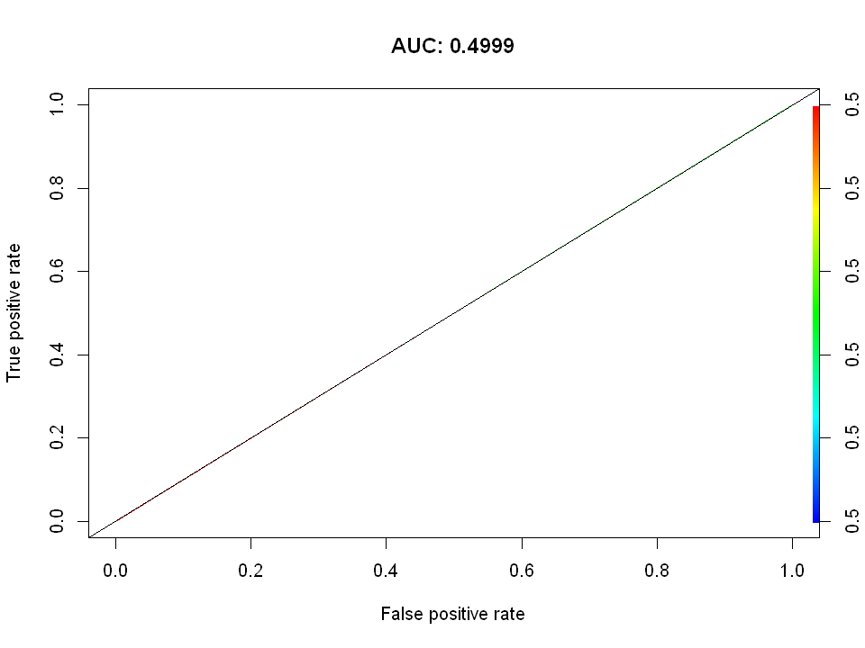

```r
#plot ROC
options(repr.plot.width=8, repr.plot.height=6)

predicted <- ifelse(log_predict > 0.5,1,0)

pred.rocr <- prediction(log_predict,new_test$CallCategory)
perf_rocr <- performance(pred.rocr, measure = "auc",
                         x.measure = "cutoff")
perf_rocr@y.values[[1]] <- round(perf_rocr@y.values[[1]], digits =
                                   4)
perf.tpr.fpr.rocr <- performance(pred.rocr, "tpr", "fpr")
plot(perf.tpr.fpr.rocr, colorize=T,
     main = paste("AUC:", (perf_rocr@y.values)))
abline(a = 0, b = 1)
```

49.99

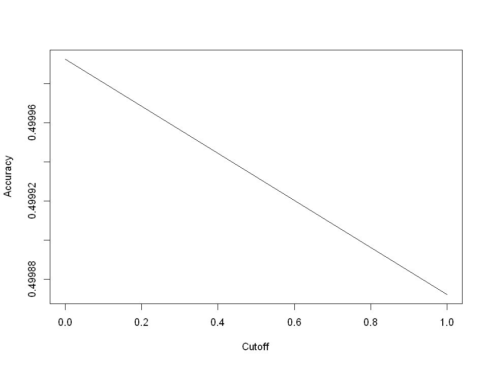

```r
# Calculating accuracy - sum of diagonal elements divided by total obs

tab <- table(Predicted = predicted, Reference = new_test$CallCategory)

round((sum(diag(tab))/sum(tab))*100,2)

pred.rocr <- prediction(predicted, new_test$CallCategory)

eval <- performance(pred.rocr, "acc")

plot(eval)
```

The accuracy for our test set comes out to be 0.500.

```r
# Identify best value (Cutoff vs Accuracy)

max <- which.max(slot(eval, "y.values")[[1]])
acc <- slot(eval, "y.values")[[1]][max] #y.values are accuracy measures
cut <- slot(eval, "x.values")[[1]][max] # x.values are cutoff measures

print(c(Accuracy = acc, Cutoff = cut))
```

```
 Accuracy    Cutoff
0.5000075       Inf
```

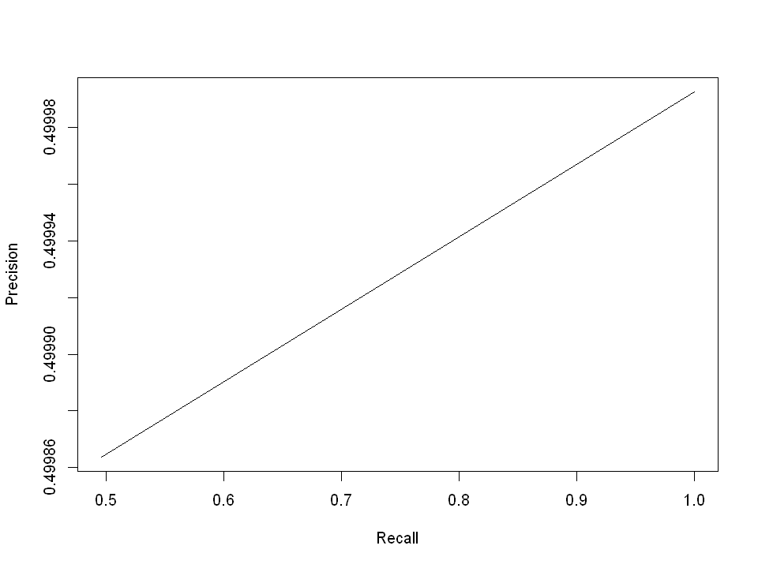

```r
RP.perf <- performance(pred.rocr, "prec", "rec");

plot (RP.perf);
```

### Prediction on Train Data

```r
#prediction on train data
log_predict1 <- predict(log_model,newdata = new_train,type = "response")
predicted1 <- ifelse(log_predict1 > 0.5,'PreQ','PostQ')
```

```r
tab1 <- table(Predicted = predicted1, Reference = new_train$CallCategory)
tab1
```

```
         Reference
Predicted PostQ  PreQ
    PostQ 67633 67621
    PreQ  65522 65534
```

```r
predicted1
```

'PostQ'

**3**

'PostQ'

**4**

'PreQ'

**5**

'PostQ'

**6**

'PostQ'

**7**

'PostQ'

**8**

'PreQ'

**9**

'PreQ'

**10**

'PreQ'

**11**

'PostQ'

**12**

'PostQ'

**13**

'PostQ'

**14**

'PreQ'

**15**

'PreQ'

**16**

'PostQ'

**17**

'PostQ'

**18**

'PreQ'

**19**

'PostQ'

**20**

'PostQ'

**21**

'PostQ'

**22**

'PostQ'

**23**

'PreQ'

**24**

'PostQ'

**25**

'PreQ'

**26**

'PostQ'

**27**

'PreQ'

**28**

'PreQ'

**29**

'PreQ'

**30**

'PostQ'

**31**

'PreQ'

**32**

'PreQ'

**33**

'PreQ'

**34**

'PostQ'

**35**

'PreQ'

**36**

'PostQ'

**37**

'PreQ'

**38**

'PostQ'

**39**

'PreQ'

**40**

'PostQ'

**41**

'PostQ'

**42**

'PostQ'

**43**

'PreQ'

**44**

'PreQ'

**45**

'PreQ'

**46**

'PreQ'

**47**

'PostQ'

**48**

'PreQ'

**49**

'PostQ'

**50**

'PreQ'

**51**

'PostQ'

**52**

'PreQ'

**53**

'PreQ'

**54**

'PostQ'

**55**

'PreQ'

**56**

'PostQ'

**57**

'PreQ'

**58**

'PostQ'

**59**

'PreQ'

**60**

'PostQ'

**61**

'PreQ'

**62**

'PreQ'

**63**

'PostQ'

**64**

'PostQ'

**65**

'PostQ'

**66**

'PreQ'

**67**

'PreQ'

**68**

'PostQ'

**69**

'PostQ'

**70**

'PostQ'

**71**

'PreQ'

**72**

'PostQ'

**73**

'PreQ'

**74**

'PostQ'

**75**

'PostQ'

**76**

'PostQ'

**77**

'PreQ'

**78**

'PreQ'

**79**

'PreQ'

**80**

'PreQ'

**81**

'PreQ'

**82**

'PreQ'

**83**

'PreQ'

**84**

'PreQ'

**85**

'PostQ'

**86**

'PreQ'

**87**

'PreQ'

**88**

'PreQ'

**89**

'PreQ'

**90**

'PreQ'

**91**

'PostQ'

**92**

'PreQ'

**93**

'PostQ'

**94**

'PostQ'

**95**

'PreQ'

**96**

'PostQ'

**97**

'PostQ'

**98**

'PostQ'

**99**

'PostQ'

**100**

'PostQ'

**101**

'PreQ'

**102**

'PostQ'

**103**

'PostQ'

**104**

'PostQ'

**105**

'PostQ'

**106**

'PreQ'

**107**

'PreQ'

**108**

'PreQ'

**109**

'PreQ'

**110**

'PreQ'

**111**

'PreQ'

**112**

'PostQ'

**113**

'PreQ'

**114**

'PreQ'

**115**

'PostQ'

**116**

'PreQ'

**117**

'PostQ'

**118**

'PostQ'

**119**

'PostQ'

**120**

'PreQ'

**121**

'PreQ'

**122**

'PreQ'

**123**

'PostQ'

**124**

'PreQ'

**125**

'PreQ'

**126**

'PostQ'

**127**

'PreQ'

**128**

'PostQ'

**129**

'PostQ'

**130**

'PostQ'

**131**

'PreQ'

**132**

'PostQ'

**133**

'PostQ'

**134**

'PostQ'

**135**

'PostQ'

**136**

'PreQ'

**137**

'PostQ'

**138**

'PostQ'

**139**

'PostQ'

**140**

'PreQ'

**141**

'PostQ'

**142**

'PreQ'

**143**

'PreQ'

**144**

'PostQ'

**145**

'PreQ'

**146**

'PostQ'

**147**

'PreQ'

**148**

'PostQ'

**149**

'PostQ'

**150**

'PostQ'

**151**

'PreQ'

**152**

'PreQ'

**153**

'PostQ'

**154**

'PreQ'

**155**

'PreQ'

**156**

'PreQ'

**157**

'PostQ'

**158**

'PostQ'

**159**

'PostQ'

**160**

'PreQ'

**161**

'PostQ'

**162**

'PreQ'

**163**

'PostQ'

**164**

'PreQ'

**165**

'PostQ'

**166**

'PreQ'

**167**

'PostQ'

**168**

'PostQ'

**169**

'PreQ'

**170**

'PostQ'

**171**

'PostQ'

**172**

'PreQ'

**173**

'PreQ'

**174**

'PostQ'

**175**

'PostQ'

**176**

'PostQ'

**177**

'PreQ'

**178**

'PreQ'

**179**

'PostQ'

**180**

'PostQ'

**181**

'PostQ'

**182**

'PostQ'

**183**

'PostQ'

**184**

'PostQ'

**185**

'PostQ'

**186**

'PostQ'

**187**

'PreQ'

**188**

'PreQ'

**189**

'PostQ'

**190**

'PostQ'

**191**

'PreQ'

**192**

'PreQ'

**193**

'PostQ'

**194**

'PostQ'

**195**

'PostQ'

**196**

'PostQ'

**197**

'PostQ'

**198**

'PostQ'

**199**

'PostQ'

**200**

'PostQ'

**202**

'PostQ'

**203**

'PreQ'

**204**

'PreQ'

**205**

'PreQ'

**206**

'PreQ'

**207**

'PostQ'

**208**

'PreQ'

**209**

'PreQ'

**210**

'PreQ'

**211**

'PostQ'

**212**

'PostQ'

**213**

'PostQ'

**214**

'PreQ'

**215**

'PostQ'

**216**

'PostQ'

**217**

'PreQ'

**218**

'PreQ'

**219**

'PostQ'

**220**

'PreQ'

**221**

'PreQ'

**222**

'PreQ'

**223**

'PreQ'

**224**

'PostQ'

**225**

'PreQ'

**226**

'PostQ'

**227**

'PostQ'

**228**

'PreQ'

**229**

'PostQ'

**230**

'PostQ'

**231**

'PostQ'

**232**

'PreQ'

**233**

'PostQ'

**234**

'PreQ'

**235**

'PreQ'

**236**

'PostQ'

**237**

'PostQ'

**238**

'PostQ'

**239**

'PostQ'

**240**

'PreQ'

**241**

'PreQ'

**242**

'PostQ'

**243**

'PreQ'

**244**

'PostQ'

**245**

'PostQ'

**246**

'PostQ'

**247**

'PreQ'

**248**

'PostQ'

**249**

'PreQ'

**250**

'PostQ'

**251**

'PreQ'

**252**

'PostQ'

**253**

'PreQ'

**254**

'PreQ'

**255**

'PostQ'

**256**

'PostQ'

**257**

'PreQ'

**258**

'PreQ'

**259**

'PostQ'

**260**

'PreQ'

**261**

'PostQ'

**262**

'PostQ'

**263**

'PreQ'

**264**

'PreQ'

**265**

'PostQ'

**266**

'PreQ'

**267**

'PostQ'

**268**

'PreQ'

**269**

'PostQ'

**270**

'PreQ'

**271**

'PreQ'

**272**

'PreQ'

**273**

'PreQ'

**274**

'PreQ'

**275**

'PostQ'

**276**

'PreQ'

**277**

'PreQ'

**278**

'PreQ'

**279**

'PostQ'

**280**

'PreQ'

**281**

'PreQ'

**282**

'PostQ'

**283**

'PostQ'

**284**

'PreQ'

**285**

'PreQ'

**286**

'PostQ'

**287**

'PostQ'

**288**

'PostQ'

**289**

'PreQ'

**290**

'PreQ'

**291**

'PreQ'

**292**

'PreQ'

**293**

'PreQ'

**294**

'PreQ'

**295**

'PostQ'

**296**

'PreQ'

**297**

'PostQ'

**298**

'PostQ'

**299**

'PostQ'

**300**

'PostQ'

**301**

'PreQ'

**302**

'PostQ'

**303**

'PostQ'

**304**

'PostQ'

**305**

'PreQ'

**306**

'PreQ'

**307**

'PostQ'

**308**

'PostQ'

**309**

'PostQ'

**310**

'PreQ'

**311**

'PreQ'

**312**

'PostQ'

**313**

'PostQ'

**314**

'PostQ'

**315**

'PostQ'

**316**

'PreQ'

**317**

'PostQ'

**318**

'PreQ'

**319**

'PreQ'

**320**

'PreQ'

**321**

'PreQ'

**322**

'PostQ'

**323**

'PreQ'

**324**

'PreQ'

**325**

'PreQ'

**326**

'PostQ'

**327**

'PreQ'

**328**

'PreQ'

**329**

'PostQ'

**330**

'PostQ'

**331**

'PostQ'

**332**

'PostQ'

**333**

'PreQ'

**334**

'PreQ'

**335**

'PostQ'

**336**

'PostQ'

**337**

'PostQ'

**338**

'PreQ'

**339**

'PreQ'

**340**

'PreQ'

**341**

'PostQ'

**342**

'PostQ'

**343**

'PreQ'

**344**

'PostQ'

**345**

'PostQ'

**346**

'PreQ'

**347**

'PostQ'

**348**

'PreQ'

**349**

'PostQ'

**350**

'PreQ'

**351**

'PreQ'

**352**

'PreQ'

**353**

'PostQ'

**354**

'PreQ'

**355**

'PostQ'

**356**

'PostQ'

**357**

'PostQ'

**358**

'PostQ'

**359**

'PreQ'

**360**

'PreQ'

**361**

'PostQ'

**362**

'PostQ'

**363**

'PostQ'

**364**

'PreQ'

**365**

'PostQ'

**366**

'PostQ'

**367**

'PostQ'

**368**

'PostQ'

**369**

'PostQ'

**370**

'PreQ'

**371**

'PreQ'

**372**

'PostQ'

**373**

'PostQ'

**374**

'PostQ'

**375**

'PostQ'

**376**

'PostQ'

**377**

'PostQ'

**378**

'PostQ'

**379**

'PostQ'

**380**

'PreQ'

**381**

'PreQ'

**382**

'PostQ'

**383**

'PostQ'

**384**

'PreQ'

**385**

'PreQ'

**386**

'PreQ'

**387**

'PostQ'

**388**

'PostQ'

**389**

'PreQ'

**390**

'PostQ'

**391**

'PostQ'

**392**

'PreQ'

**393**

'PreQ'

**394**

'PostQ'

**395**

'PostQ'

**396**

'PostQ'

**397**

'PreQ'

**398**

'PreQ'

**399**

'PostQ'

**400**

'PostQ'

**401**

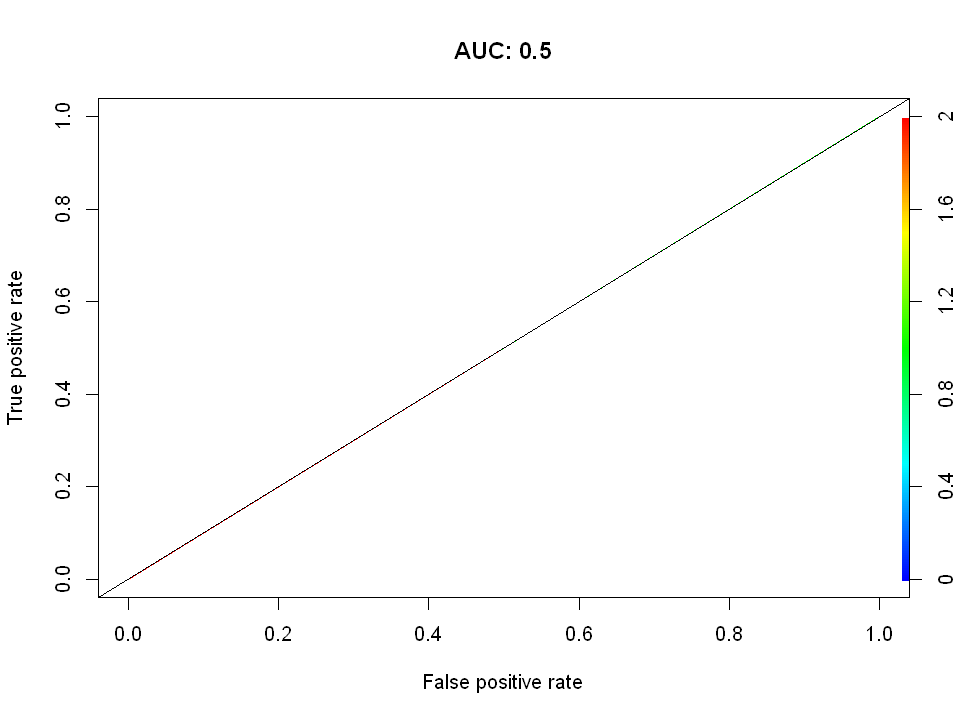

```r
#plot ROC
predicted1 <- ifelse(log_predict1 > 0.5,1,0)
pred.rocr1 <- prediction(predicted1,new_train$CallCategory)
perf_rocr1 <- performance(pred.rocr1, measure = "auc",
                         x.measure = "cutoff")
perf_rocr1@y.values[[1]] <- round(perf_rocr1@y.values[[1]], digits =
                                   4)
perf.tpr.fpr.rocr1 <- performance(pred.rocr1, "tpr", "fpr")
plot(perf.tpr.fpr.rocr1, colorize=T,
     main = paste("AUC:", (perf_rocr1@y.values)))
abline(a = 0, b = 1)
```

The accuracy of the train set comes out to be 0.50.

50

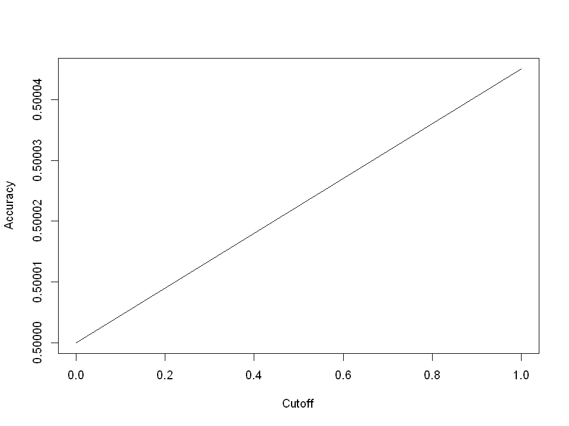

```r
# Calculating accuracy - sum of diagonal elements divided by total obs
tab1 <- table(Predicted = predicted1, Reference = new_train$CallCategory)

round((sum(diag(tab1))/sum(tab1))*100,2)

pred.rocr1 <- prediction(predicted1, new_train$CallCategory)

eval1 <- performance(pred.rocr1, "acc")

plot(eval1)
```

```r
# Identify best value (Cutoff vs Accuracy)

max1 <- which.max(slot(eval1, "y.values")[[1]])
acc1 <- slot(eval1, "y.values")[[1]][max1] #y.values are accuracy measures
cut1 <- slot(eval1, "x.values")[[1]][max1] # x.values are cutoff measures

print(c(Accuracy = acc1, Cutoff = cut1))
```

```
     Accuracy Cutoff.266310
    0.5000451     1.0000000
```

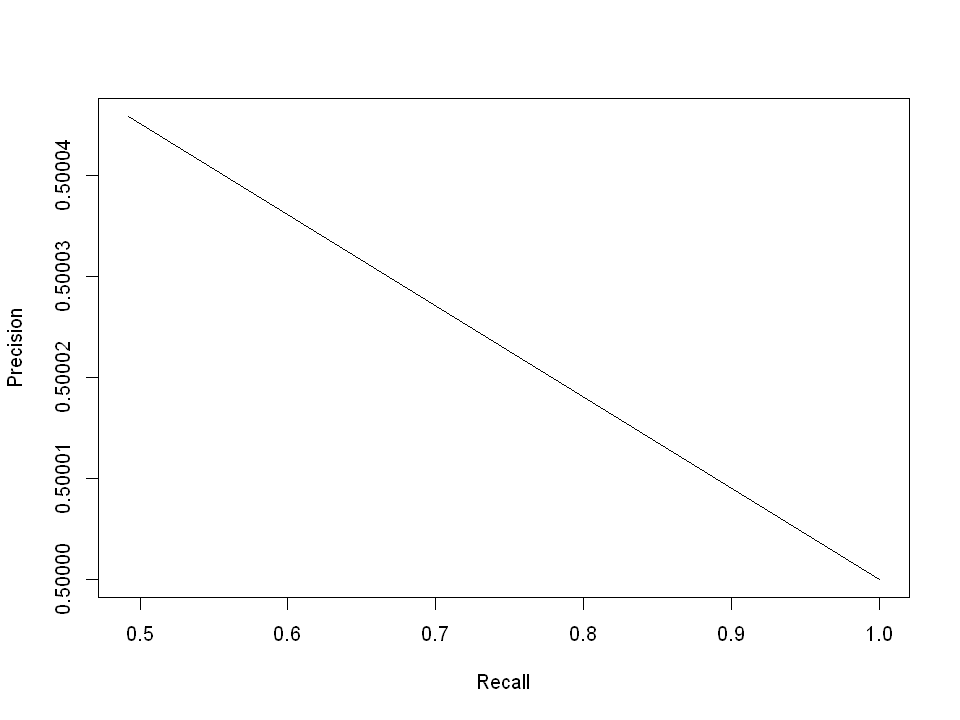

```r
RP.perf1 <- performance(pred.rocr1, "prec", "rec");

plot (RP.perf1);
```

### References:

[1] https://www.statisticssolutions.com/non-parametric-analysis-chi-square/

[2] http://www.acastat.com/statbook/chisqassoc.htm

[3] https://www.statisticshowto.com/point-biserial-correlation/

[4] https://online.stat.psu.edu/stat504/node/216/

[5] https://towardsdatascience.com/modelling-binary-logistic-regression-using-r-research-oriented-modelling-and-interpretation-f67b3a954101

[6] https://thestatsgeek.com/2014/02/08/r-squared-in-logistic-regression/

[7] https://towardsdatascience.com/simply-explained-logistic-regression-with-example-in-r-b919acb1d6b3

[8] https://data.princeton.edu/r/glms

[9] https://www.rdocumentation.org/packages/lmtest/versions/0.9-37/topics/dwtest